# 텀프로젝트1_데이터분석(2020105741_한주상)

```python
!pip install --upgrade scikit-learn
!pip install --upgrade pandas
!pip install --upgrade imbalanced-learn
!pip install matplotlib
!g++ --version
!java -version
!pip install --upgrade pip
!curl --version
!git --version
!pip install konlpy
!pip install statsmodels
!pip install seaborn
!pip install openpyxl
```

```
g++ (MinGW.org GCC-6.3.0-1) 6.3.0
Copyright (C) 2016 Free Software Foundation, Inc.
This is free software; see the source for copying conditions.  There is NO
warranty; not even for MERCHANTABILITY or FITNESS FOR A PARTICULAR PURPOSE.
```

```
java version "17.0.15" 2025-04-15 LTS
Java(TM) SE Runtime Environment (build 17.0.15+9-LTS-241)
Java HotSpot(TM) 64-Bit Server VM (build 17.0.15+9-LTS-241, mixed mode, sharing)
```

```
  Using cached pip-25.0.1-py3-none-any.whl.metadata (3.7 kB)
Using cached pip-25.0.1-py3-none-any.whl (1.8 MB)
```

```
ERROR: To modify pip, please run the following command:
C:\Users\hjs00\anaconda3\envs\ada\python.exe -m pip install --upgrade pip
```

```
curl 8.13.0 (Windows) libcurl/8.13.0 Schannel zlib/1.3.1 WinIDN
Release-Date: 2025-04-02
Protocols: dict file ftp ftps http https imap imaps ipfs ipns mqtt pop3 pop3s smb smbs smtp smtps telnet tftp ws wss
Features: alt-svc AsynchDNS HSTS HTTPS-proxy IDN IPv6 Kerberos Largefile libz NTLM SPNEGO SSL SSPI threadsafe Unicode UnixSockets
git version 2.42.0.windows.2
```

```python
import os
import shutil

cache_dir = os.path.expanduser("~\\.matplotlib")  # 또는 "~\\.cache\\matplotlib"
shutil.rmtree(cache_dir, ignore_errors=True)
```

```python
import matplotlib.font_manager as fm
for font in fm.findSystemFonts(fontpaths=None, fontext='ttf'):
    if 'Nanum' in font:
        print(font)
```

```
C:\Windows\Fonts\NanumGothicLight.ttf
C:\Users\hjs00\AppData\Local\Microsoft\Windows\Fonts\NanumGothicCoding.ttf
C:\Windows\Fonts\NanumMyeongjoExtraBold.ttf
C:\Users\hjs00\AppData\Local\Microsoft\Windows\Fonts\NanumGothicCoding-Bold.ttf
C:\Windows\Fonts\NanumGothicBold.ttf
C:\Windows\Fonts\NanumGothicExtraBold.ttf
C:\Windows\Fonts\NanumMyeongjo.ttf
C:\Users\hjs00\AppData\Local\Microsoft\Windows\Fonts\NanumMyeongjo_0.ttf
C:\Windows\Fonts\NanumGothic.ttf
C:\Windows\Fonts\NanumMyeongjoBold.ttf
```

```python
# 모든 모듈 호출
import pandas as pd
from sklearn.metrics import confusion_matrix, accuracy_score, precision_score, recall_score, f1_score, roc_auc_score, RocCurveDisplay, silhouette_score
from statsmodels.stats.outliers_influence import variance_inflation_factor
import numpy as np
import matplotlib.pyplot as plt
import seaborn as sns
from scipy import stats
from sklearn.model_selection import train_test_split, cross_val_score, GridSearchCV
import warnings
warnings.filterwarnings(action='ignore')
from sklearn.naive_bayes import GaussianNB
from sklearn.feature_extraction.text import TfidfVectorizer
from sklearn.preprocessing import LabelEncoder, StandardScaler, MinMaxScaler, PolynomialFeatures
from sklearn.linear_model import LogisticRegression, LinearRegression, Ridge, Lasso, ElasticNet
from sklearn.svm import SVC, SVR
from sklearn.tree import DecisionTreeClassifier, DecisionTreeRegressor
from sklearn.ensemble import RandomForestRegressor, RandomForestClassifier, BaggingClassifier, BaggingRegressor, StackingClassifier, StackingRegressor, VotingClassifier, VotingRegressor
from sklearn.cluster import KMeans, DBSCAN
from sklearn.metrics.cluster import completeness_score, homogeneity_score, v_measure_score
from sklearn.neighbors import KNeighborsClassifier
import matplotlib.font_manager as fm
from imblearn.over_sampling import SMOTE, ADASYN
import os
import math
import re
from konlpy.tag import Okt
from sklearn.feature_extraction.text import CountVectorizer
plt.rc('font', family='NanumGothicCoding')
plt.rcParams['axes.unicode_minus'] =False
```

```python
#Data Loading
df = pd.read_excel('news.xlsx')
df.head()
```

|  | ott_type | year | month | day | source | title | comment | label |
| --- | --- | --- | --- | --- | --- | --- | --- | --- |
| 0 | 넷플릭스 | 2020 | 6 | 5 | Samsung SDS | 넷플릭스로 알아보는 MSA \| 인사이트리포트 \| 삼성SDS | 개발자가 폴백 메소드를 구현함으로써 시스템 장애로부터 유연하게 복구를 실행할 수 있... | 1 |
| 1 | 넷플릭스 | 2020 | 12 | 15 | AI타임스 | 넷플릭스, AI 시스템으로 얼마만큼 흥행할 지 예상한다 | 넷플릭스는 영화ᆞ드라마 주제를 비교하기 위해 AI가 영상 메타데이터(설명데이터), ... | 1 |
| 2 | 넷플릭스 | 2020 | 3 | 22 | About Netflix | 넷플릭스, 한국 최고의 스토리 한자리에 모으다 | 넷플릭스, 한국 최고의 스토리 한자리에 모으다 · 한국/아시아 태평양 지역/모든 영... | 1 |
| 3 | 넷플릭스 | 2020 | 1 | 28 | 중앙일보 | 한국 넷플릭스에선 볼 수 있는 토토로, 美·日선 못 본다 왜? | 지브리 명작 21편, 넷플릭스로 본다. 오는 2월부터 한국 포함 약 190개국 넷플... | 0 |
| 4 | 넷플릭스 | 2020 | 12 | 31 | 브런치스토리 | # 나의 넷플릭스 시청 연대기 | # 나의 넷플릭스 시청 연대기 · 1. 간만 보려 했다가 카운터 펀치를 당하다 <하... | 1 |

```python
df.info()
```

```
<class 'pandas.core.frame.DataFrame'>
RangeIndex: 4185 entries, 0 to 4184
Data columns (total 8 columns):
 #   Column    Non-Null Count  Dtype
---  ------    --------------  -----
 0   ott_type  4185 non-null   object
 1   year      4185 non-null   int64
 2   month     4185 non-null   int64
 3   day       4185 non-null   int64
 4   source    4185 non-null   object
 5   title     4185 non-null   object
 6   comment   4185 non-null   object
 7   label     4185 non-null   int64
dtypes: int64(4), object(4)
memory usage: 261.7+ KB
```

```python
df.describe()
```

|  | year | month | day | label |
| --- | --- | --- | --- | --- |
| count | 4185.00000 | 4185.000000 | 4185.000000 | 4185.000000 |
| mean | 2022.03417 | 8.566308 | 16.063082 | 0.841099 |
| std | 1.35625 | 2.964652 | 8.705827 | 0.365627 |
| min | 2020.00000 | 1.000000 | 1.000000 | 0.000000 |
| 25% | 2021.00000 | 7.000000 | 9.000000 | 1.000000 |
| 50% | 2022.00000 | 9.000000 | 16.000000 | 1.000000 |
| 75% | 2023.00000 | 11.000000 | 23.000000 | 1.000000 |
| max | 2024.00000 | 12.000000 | 31.000000 | 1.000000 |

```python
df = df.drop('source', axis=1)
```

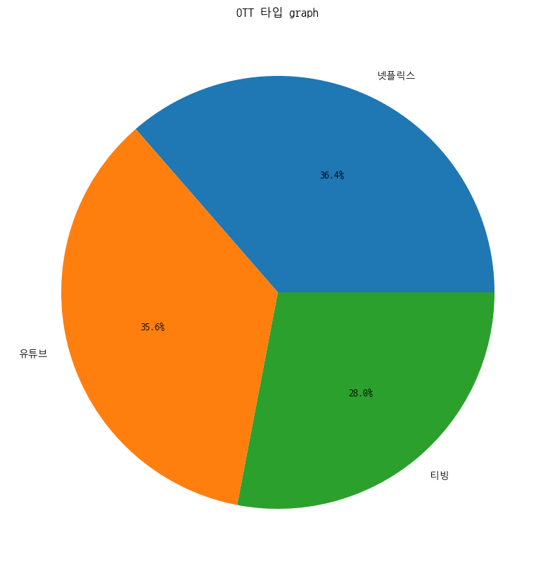

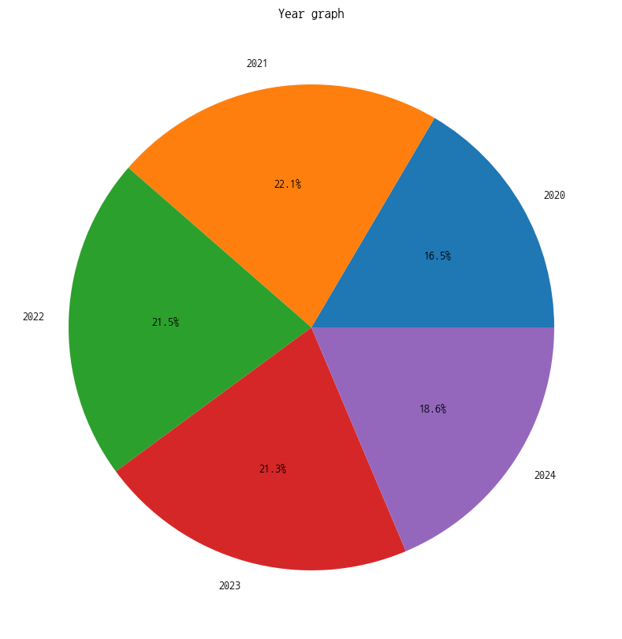

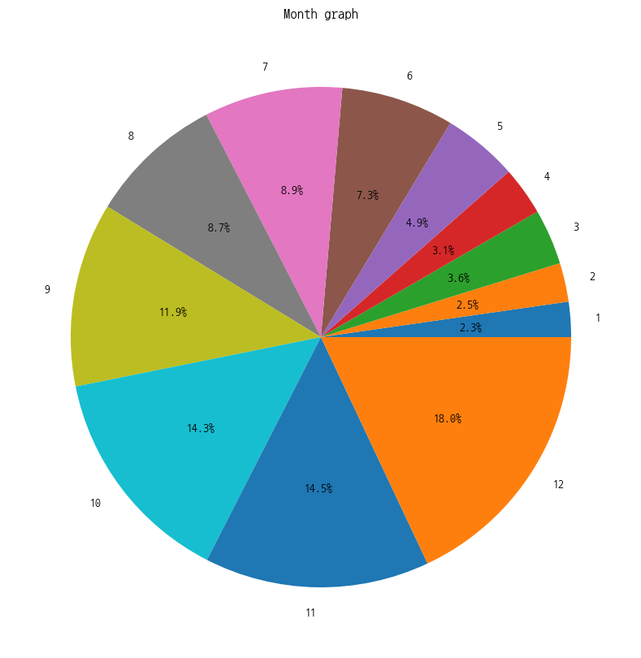

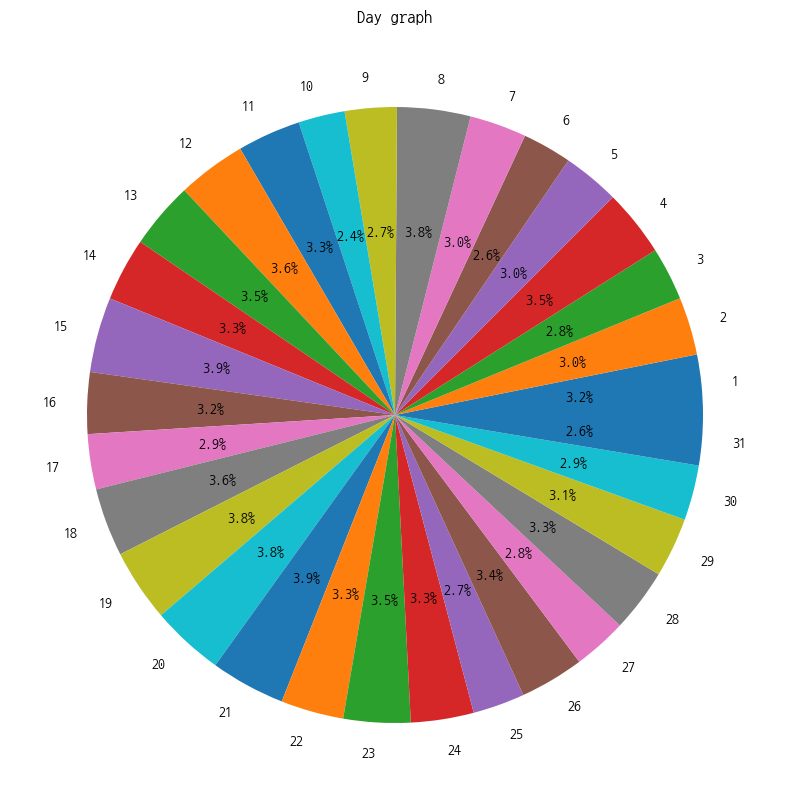

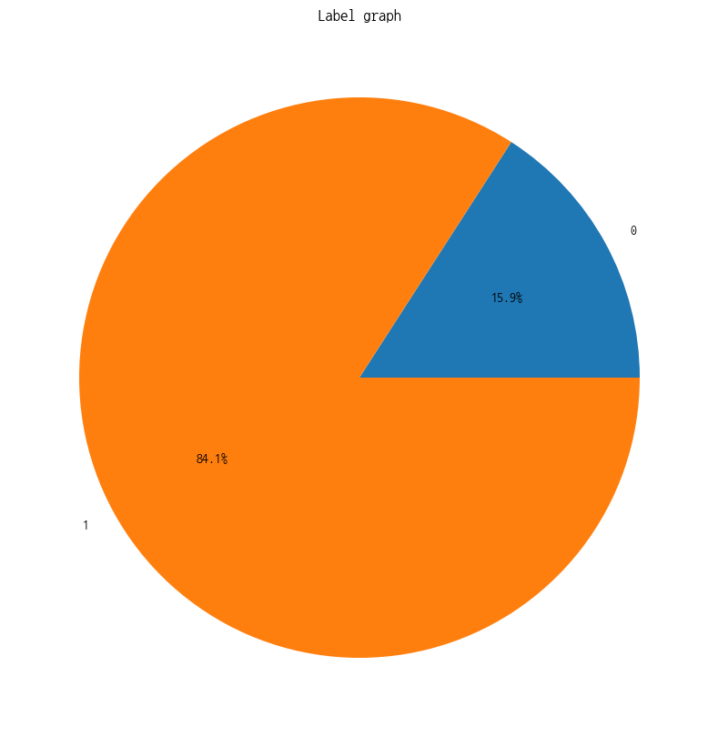

```python
# OTT별 시각화
df_ott = df.groupby(['ott_type'])['ott_type'].count()
df_ott = df_ott.to_frame(name='count')
plt.figure(figsize=(15, 10))
plt.pie(df_ott['count'],labels=df_ott.index, autopct='%.1f%%')
plt.title('OTT 타입 graph')
plt.grid()
plt.show()

# year별 시각화
df_year = df.groupby(['year'])['year'].count()
df_year = df_year.to_frame(name='count')
plt.figure(figsize=(15, 10))
plt.pie(df_year['count'],labels=df_year.index, autopct='%.1f%%')
plt.title('Year graph')
plt.grid()
plt.show()

# month별 시각화
df_month = df.groupby(['month'])['month'].count()
df_month = df_month.to_frame(name='count')
plt.figure(figsize=(15, 10))
plt.pie(df_month['count'],labels=df_month.index, autopct='%.1f%%')
plt.title('Month graph')
plt.grid()
plt.show()

# day별 시각화
df_day = df.groupby(['day'])['day'].count()
df_day = df_day.to_frame(name='count')
plt.figure(figsize=(15, 10))
plt.pie(df_day['count'],labels=df_day.index, autopct='%.1f%%')
plt.title('Day graph')
plt.grid()
plt.show()

# label별 시각화
df_label = df.groupby(['label'])['label'].count()
df_label = df_label.to_frame(name='count')
plt.figure(figsize=(15, 10))
plt.pie(df_label['count'],labels=df_label.index, autopct='%.1f%%')
plt.title('Label graph')
plt.grid()
plt.show()
```

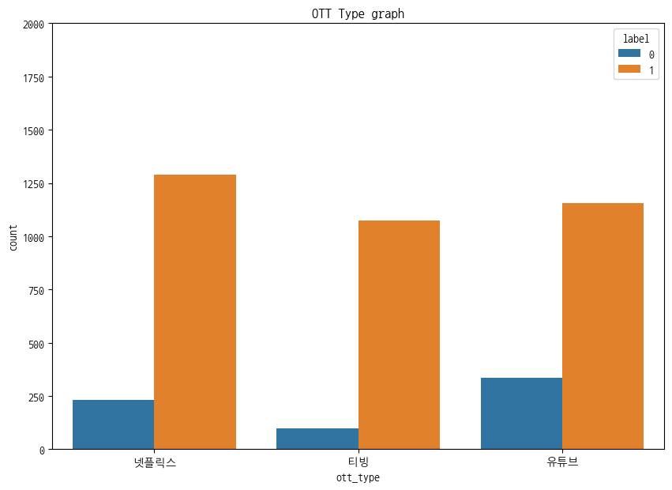

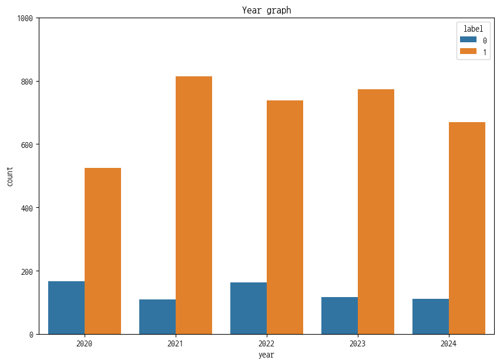

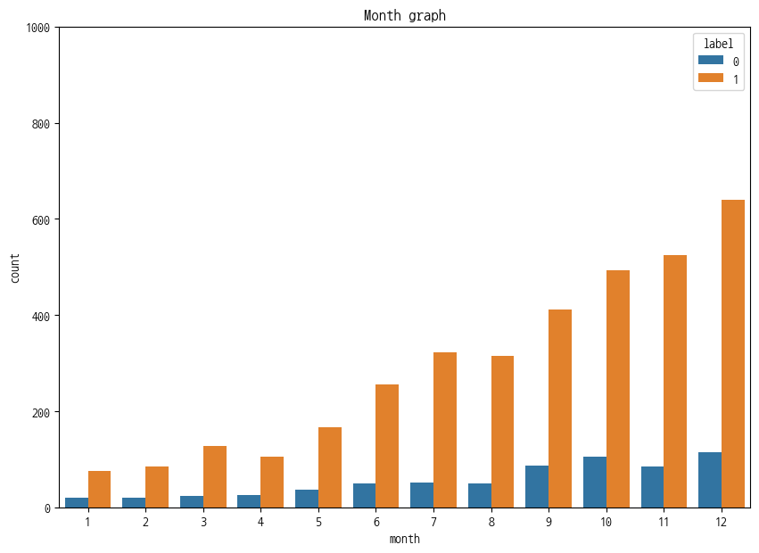

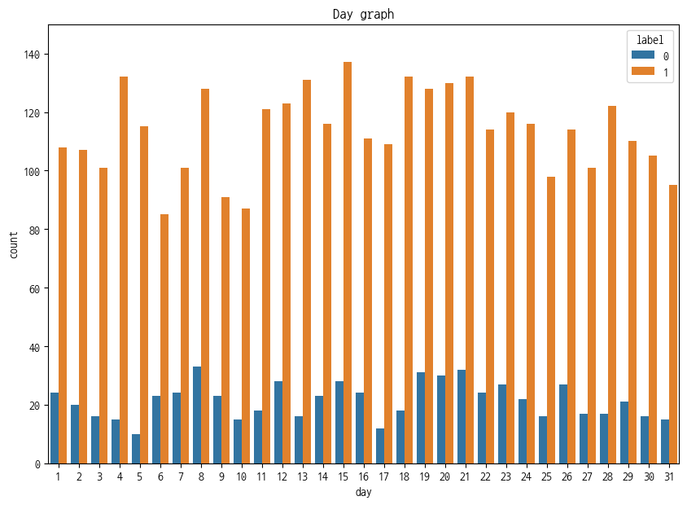

```python
# 이상치 측정
# OTT별 분류 분포
plt.figure(figsize = (10, 7))
plt.title('OTT Type graph')
sns.countplot(data=df, x='ott_type', hue='label')
plt.ylim(0, 2000)
plt.show()

# 연별 분류 분포
plt.figure(figsize = (10, 7))
plt.title('Year graph')
sns.countplot(data=df, x='year', hue='label')
plt.ylim(0, 1000)
plt.show()

# 월별 분류 분포
plt.figure(figsize = (10, 7))
plt.title('Month graph')
sns.countplot(data=df, x = 'month', hue = 'label')
plt.ylim(0, 1000)
plt.show()

# 일별 대여수 분포
plt.figure(figsize = (10, 7))
plt.title('Day graph')
sns.countplot(data = df, x='day', hue='label')
plt.ylim(0, 150)
plt.show()
```

### 이상치 확인

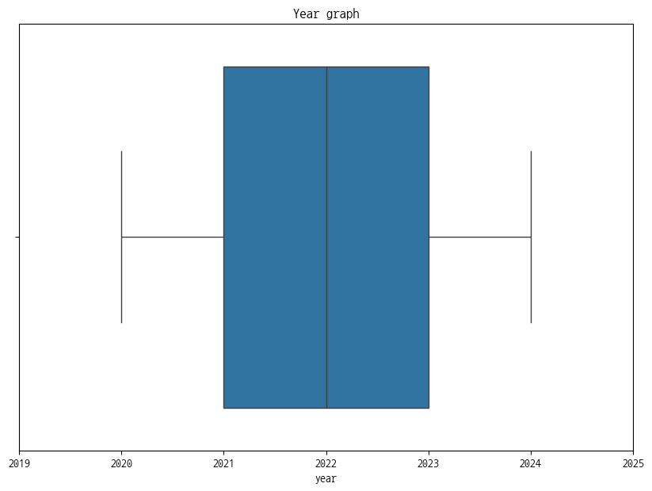

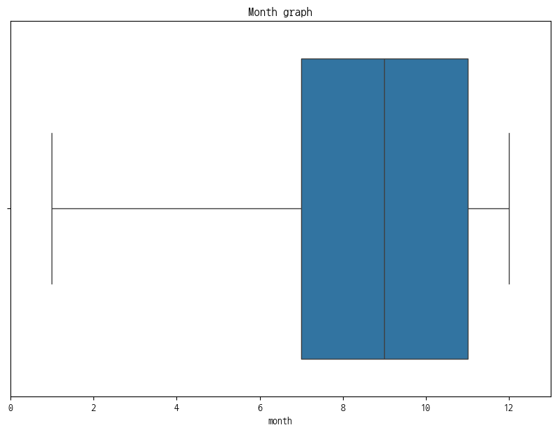

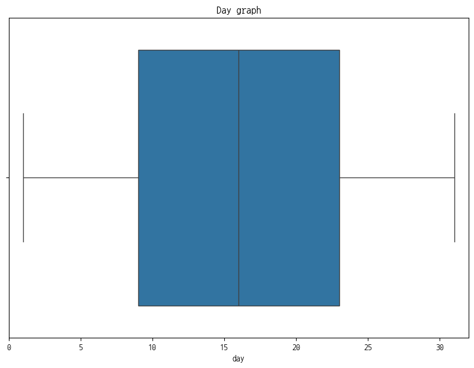

```python
# 이상치 분포 확인
# 연별 대여수 분포
plt.figure(figsize = (10, 7))
sns.boxplot(x='year', data=df)
plt.xlim(2019, 2025)
plt.title('Year graph')
plt.show()

# 월별 대여수 분포
plt.figure(figsize = (10, 7))
sns.boxplot(x='month', data = df)
plt.xlim(0, 13)
plt.title('Month graph')
plt.show()

# 일별 대여수 분포
plt.figure(figsize = (10, 7))
sns.boxplot(x='day', data = df)
plt.xlim(0, 32)
plt.title('Day graph')
plt.show()
```

```python
df_year_month_day1 = df[['year', 'month', 'day']]
# outlier processing 확인
# z-score 이용
standardizer_year_month_day = StandardScaler()
df_year_month_day1 = standardizer_year_month_day.fit_transform(df_year_month_day1)
df_year_month_day1 = pd.DataFrame(df_year_month_day1, columns=['year', 'month', 'day'])
# year z-score 확인
print("모든 Year에 대한  Z-Score 확인")
print()
print(df_year_month_day1['year'].value_counts(ascending=True))
print("-----------------------------------------------------------------------------------------")
# month z-score 확인
print("모든 Month에 대한 Z-Score 확인")
print()
print(df_year_month_day1['month'].value_counts(ascending=True))
print("-----------------------------------------------------------------------------------------")
# day z-score 확인
print("모든 Day에 대한 Z-Score 확인")
print()
print(df_year_month_day1['day'].value_counts(ascending=True))
print("-----------------------------------------------------------------------------------------")
# IQR 확인
# year의 확인
year_q1 = df['year'].quantile(0.25)
year_q3 = df['year'].quantile(0.75)
year_iqr = year_q3 - year_q1
print(f"모든 year의 1사분위수: {year_q1}")
print(f"모든 year의 3사분위수: {year_q3}")
print(f"모든 year의 IQR의 값: {year_iqr}")
print("-----------------------------------------------------------------------------------------")
# month의 확인
month_q1 = df['month'].quantile(0.25)
month_q3 = df['month'].quantile(0.75)
month_iqr = month_q3 - month_q1
print(f"모든 month의 1사분위수: {month_q1}")
print(f"모든 month의 3사분위수: {month_q3}")
print(f"모든 month의 IQR의 값: {month_iqr}")
print("-----------------------------------------------------------------------------------------")
# day의 확인
day_q1 = df['day'].quantile(0.25)
day_q3 = df['day'].quantile(0.75)
day_iqr = day_q3 - day_q1
print(f"모든 day의 1사분위수: {day_q1}")
print(f"모든 day의 3사분위수: {day_q3}")
print(f"모든 day의 IQR의 값: {day_iqr}")
print("-----------------------------------------------------------------------------------------")
```

```
모든 Year에 대한  Z-Score 확인

year
-1.500027    692
 1.449633    780
 0.712218    890
-0.025197    900
-0.762612    923
Name: count, dtype: int64
-----------------------------------------------------------------------------------------
모든 Month에 대한 Z-Score 확인

month
-2.552479     95
-2.215131    105
-1.540435    131
-1.877783    150
-1.203087    203
-0.865739    305
-0.191043    364
-0.528391    374
 0.146305    498
 0.483653    599
 0.821001    608
 1.158349    753
Name: count, dtype: int64
-----------------------------------------------------------------------------------------
모든 Day에 대한 Z-Score 확인

day
-0.696523    102
-1.156040    108
 1.715943    110
 1.026667    114
-0.811402    114
-1.500678    117
 1.256426    118
 1.601064    121
 0.107632    121
-1.270919    125
```

[output cut: 20 more lines]

```
-0.122126    165
Name: count, dtype: int64
-----------------------------------------------------------------------------------------
모든 year의 1사분위수: 2021.0
모든 year의 3사분위수: 2023.0
모든 year의 IQR의 값: 2.0
-----------------------------------------------------------------------------------------
모든 month의 1사분위수: 7.0
모든 month의 3사분위수: 11.0
모든 month의 IQR의 값: 4.0
-----------------------------------------------------------------------------------------
모든 day의 1사분위수: 9.0
모든 day의 3사분위수: 23.0
모든 day의 IQR의 값: 14.0
-----------------------------------------------------------------------------------------
```

Year, Month, Day에 대해서 Outlier가 있는지 확인하기 위해서 Z-score로도 분석을 해 보았다. 그 결과, year, day일 때에는 아예 없다. month의 경우에는 200개의 표본이 절댓값 2보다 크다는 것을 확인할 수 있었다.

### 가설1: OTT에서 시간대에 따라서 년/월/일에 따라서 OTT가 긍정적인지 부정적인지가 달라질 것이다.(분류(Classification) 방법 & 가설 검정(One Sample & Two Sample T-test))

```python
# 잠깐 분류/회귀로 예측
X = df.loc[:, ['year', 'month', 'day']]
y = df.loc[:, 'label']
X_train, X_test, y_train, y_test = train_test_split(X, y, test_size=0.33, random_state=42)
min_max = MinMaxScaler()
X_train = min_max.fit_transform(X_train)
```

year, month, day에 대해서 X, y를 통해서 분류방법을 이용하여 여러 가지 모델을 수행을 하였습니다.

#### Logistic Regression(Classification)

```python
lgc = LogisticRegression(random_state=42)
lgc.fit(X_train, y_train)
pred_y = lgc.predict(X_test)
cf_matrix = confusion_matrix(y_test.values, pred_y)

# annotation 준비
group_names = ["TN", "FP (type 1 error)", "FN (type 2 error)", "TP"]
group_counts = [value for value in cf_matrix.flatten()]
group_percentages = [f"{value:.1%}" for value in cf_matrix.flatten()/np.sum(cf_matrix)]
labels = [f"{v1}\n{v2}\n({v3})" for v1, v2, v3 in zip(group_names,group_counts,group_percentages)]
labels = np.asarray(labels).reshape(2,2)

# Metrics 출력
print("Metrics 출력")
print("Accuracy Score", accuracy_score(y_test, pred_y))
print("Precision Score", precision_score(y_test, pred_y))
print("Recall Score", recall_score(y_test, pred_y))
print("F1 Score", f1_score(y_test, pred_y))
print("ROC AUC Score", roc_auc_score(y_test, pred_y))
TN, FP, FN, TP = cf_matrix.ravel()
TPR = TP / (TP+FN)
FPR = FP / (FP+TN)
print("TPR", TPR)
print("FPR", FPR)
print("------------------------------------------------------------------")

# Confusion Matrix 시각화
sns.heatmap(cf_matrix, annot=labels, fmt='', cmap='Blues')
plt.xlabel('Predicted Label')
plt.ylabel('True Label')
```

[output not shown]

```
Metrics 출력
Accuracy Score 0.8574529667149059
Precision Score 0.8574529667149059
Recall Score 1.0
F1 Score 0.9232567199065057
ROC AUC Score 0.5
TPR 1.0
FPR 1.0
------------------------------------------------------------------
```

#### DecisionTreeClassifier(Classification)

```python
dtc = DecisionTreeClassifier(random_state=42)
dtc.fit(X_train, y_train)
pred_y = dtc.predict(X_test)
cf_matrix = confusion_matrix(y_test.values, pred_y)

# annotation 준비
group_names = ["TN", "FP (type 1 error)", "FN (type 2 error)", "TP"]
group_counts = [value for value in cf_matrix.flatten()]
group_percentages = [f"{value:.1%}" for value in cf_matrix.flatten()/np.sum(cf_matrix)]
labels = [f"{v1}\n{v2}\n({v3})" for v1, v2, v3 in zip(group_names,group_counts,group_percentages)]
labels = np.asarray(labels).reshape(2,2)

# Metrics 출력
print("Metrics 출력")
print("Accuracy Score", accuracy_score(y_test, pred_y))
print("Precision Score", precision_score(y_test, pred_y))
print("Recall Score", recall_score(y_test, pred_y))
print("F1 Score", f1_score(y_test, pred_y))
print("ROC AUC Score", roc_auc_score(y_test, pred_y))
TN, FP, FN, TP = cf_matrix.ravel()
TPR = TP / (TP+FN)
FPR = FP / (FP+TN)
print("TPR", TPR)
print("FPR", FPR)
print("------------------------------------------------------------------")

# Confusion Matrix 시각화
sns.heatmap(cf_matrix, annot=labels, fmt='', cmap='Blues')
plt.xlabel('Predicted Label')
plt.ylabel('True Label')
```

[output not shown]

```
Metrics 출력
Accuracy Score 0.8574529667149059
Precision Score 0.8574529667149059
Recall Score 1.0
F1 Score 0.9232567199065057
ROC AUC Score 0.5
TPR 1.0
FPR 1.0
------------------------------------------------------------------
```

#### SVM(Classification)

```python
svc = SVC(kernel='linear', random_state=42)
svc.fit(X_train, y_train)
pred_y = svc.predict(X_test)
cf_matrix = confusion_matrix(y_test.values, pred_y)

# annotation 준비
group_names = ["TN", "FP (type 1 error)", "FN (type 2 error)", "TP"]
group_counts = [value for value in cf_matrix.flatten()]
group_percentages = [f"{value:.1%}" for value in cf_matrix.flatten()/np.sum(cf_matrix)]
labels = [f"{v1}\n{v2}\n({v3})" for v1, v2, v3 in zip(group_names,group_counts,group_percentages)]
labels = np.asarray(labels).reshape(2,2)

# Metrics 출력
print("Metrics 출력")
print("Accuracy Score", accuracy_score(y_test, pred_y))
print("Precision Score", precision_score(y_test, pred_y))
print("Recall Score", recall_score(y_test, pred_y))
print("F1 Score", f1_score(y_test, pred_y))
print("ROC AUC Score", roc_auc_score(y_test, pred_y))
TN, FP, FN, TP = cf_matrix.ravel()
TPR = TP / (TP+FN)
FPR = FP / (FP+TN)
print("TPR", TPR)
print("FPR", FPR)
print("------------------------------------------------------------------")

# Confusion Matrix 시각화
sns.heatmap(cf_matrix, annot=labels, fmt='', cmap='Blues')
plt.xlabel('Predicted Label')
plt.ylabel('True Label')
```

[output not shown]

```
Metrics 출력
Accuracy Score 0.8574529667149059
Precision Score 0.8574529667149059
Recall Score 1.0
F1 Score 0.9232567199065057
ROC AUC Score 0.5
TPR 1.0
FPR 1.0
------------------------------------------------------------------
```

#### Random Forest Classifier(Classification)

```python
rfc = RandomForestClassifier(random_state=42)
rfc.fit(X_train, y_train)
pred_y = rfc.predict(X_test)
cf_matrix = confusion_matrix(y_test.values, pred_y)

# annotation 준비
group_names = ["TN", "FP (type 1 error)", "FN (type 2 error)", "TP"]
group_counts = [value for value in cf_matrix.flatten()]
group_percentages = [f"{value:.1%}" for value in cf_matrix.flatten()/np.sum(cf_matrix)]
labels = [f"{v1}\n{v2}\n({v3})" for v1, v2, v3 in zip(group_names,group_counts,group_percentages)]
labels = np.asarray(labels).reshape(2,2)

# Metrics 출력
print("Metrics 출력")
print("Accuracy Score", accuracy_score(y_test, pred_y))
print("Precision Score", precision_score(y_test, pred_y))
print("Recall Score", recall_score(y_test, pred_y))
print("F1 Score", f1_score(y_test, pred_y))
print("ROC AUC Score", roc_auc_score(y_test, pred_y))
TN, FP, FN, TP = cf_matrix.ravel()
TPR = TP / (TP+FN)
FPR = FP / (FP+TN)
print("TPR", TPR)
print("FPR", FPR)
print("------------------------------------------------------------------")

# Confusion Matrix 시각화
sns.heatmap(cf_matrix, annot=labels, fmt='', cmap='Blues')
plt.xlabel('Predicted Label')
plt.ylabel('True Label')
```

[output not shown]

```
Metrics 출력
Accuracy Score 0.8574529667149059
Precision Score 0.8574529667149059
Recall Score 1.0
F1 Score 0.9232567199065057
ROC AUC Score 0.5
TPR 1.0
FPR 1.0
------------------------------------------------------------------
```

#### KNeighborsClassifier(KNN Classifier)(Classification)

```python
knn_c = KNeighborsClassifier()
knn_c.fit(X_train, y_train)
pred_y = knn_c.predict(X_test)
cf_matrix = confusion_matrix(y_test.values, pred_y)

# annotation 준비
group_names = ["TN", "FP (type 1 error)", "FN (type 2 error)", "TP"]
group_counts = [value for value in cf_matrix.flatten()]
group_percentages = [f"{value:.1%}" for value in cf_matrix.flatten()/np.sum(cf_matrix)]
labels = [f"{v1}\n{v2}\n({v3})" for v1, v2, v3 in zip(group_names,group_counts,group_percentages)]
labels = np.asarray(labels).reshape(2,2)

# Metrics 출력
print("Metrics 출력")
print("Accuracy Score", accuracy_score(y_test, pred_y))
print("Precision Score", precision_score(y_test, pred_y))
print("Recall Score", recall_score(y_test, pred_y))
print("F1 Score", f1_score(y_test, pred_y))
print("ROC AUC Score", roc_auc_score(y_test, pred_y))
TN, FP, FN, TP = cf_matrix.ravel()
TPR = TP / (TP+FN)
FPR = FP / (FP+TN)
print("TPR", TPR)
print("FPR", FPR)
print("------------------------------------------------------------------")

# Confusion Matrix 시각화
sns.heatmap(cf_matrix, annot=labels, fmt='', cmap='Blues')
plt.xlabel('Predicted Label')
plt.ylabel('True Label')
```

[output not shown]

```
Metrics 출력
Accuracy Score 0.8574529667149059
Precision Score 0.8574529667149059
Recall Score 1.0
F1 Score 0.9232567199065057
ROC AUC Score 0.5
TPR 1.0
FPR 1.0
------------------------------------------------------------------
```

#### GaussianNB(Naive Bayes)(Classification)

```python
navie_bayes = GaussianNB()
navie_bayes.fit(X_train, y_train)
pred_y = navie_bayes.predict(X_test)
cf_matrix = confusion_matrix(y_test.values, pred_y)

# annotation 준비
group_names = ["TN", "FP (type 1 error)", "FN (type 2 error)", "TP"]
group_counts = [value for value in cf_matrix.flatten()]
group_percentages = [f"{value:.1%}" for value in cf_matrix.flatten()/np.sum(cf_matrix)]
labels = [f"{v1}\n{v2}\n({v3})" for v1, v2, v3 in zip(group_names,group_counts,group_percentages)]
labels = np.asarray(labels).reshape(2,2)

# Metrics 출력
print("Metrics 출력")
print("Accuracy Score", accuracy_score(y_test, pred_y))
print("Precision Score", precision_score(y_test, pred_y))
print("Recall Score", recall_score(y_test, pred_y))
print("F1 Score", f1_score(y_test, pred_y))
print("ROC AUC Score", roc_auc_score(y_test, pred_y))
TN, FP, FN, TP = cf_matrix.ravel()
TPR = TP / (TP+FN)
FPR = FP / (FP+TN)
print("TPR", TPR)
print("FPR", FPR)
print("------------------------------------------------------------------")

# Confusion Matrix 시각화
sns.heatmap(cf_matrix, annot=labels, fmt='', cmap='Blues')
plt.xlabel('Predicted Label')
plt.ylabel('True Label')
```

[output not shown]

```
Metrics 출력
Accuracy Score 0.14254703328509408
Precision Score 0.0
Recall Score 0.0
F1 Score 0.0
ROC AUC Score 0.5
TPR 0.0
FPR 0.0
------------------------------------------------------------------
```

#### Ensemble - Hard Voting

```python
clf1 = LogisticRegression(random_state=42)
clf2 = RandomForestClassifier(random_state=42)
clf3 = GaussianNB()
clf4 = SVC(kernel='linear', probability=True, random_state=42)  # soft voting을 위해선 probability=True 필요
clf5 = KNeighborsClassifier()

voting_clf = VotingClassifier(
    estimators=[
        ('log_reg', clf1),
        ('ran_fst', clf2),
        ('gau_nb', clf3),
        ('svc', clf4),
        ('knn', clf5)
    ],
    voting='hard'
)
voting_clf.fit(X_train, y_train)
pred_y = voting_clf.predict(X_test)
cf_matrix = confusion_matrix(y_test.values, pred_y)

# annotation 준비
group_names = ["TN", "FP (type 1 error)", "FN (type 2 error)", "TP"]
group_counts = [value for value in cf_matrix.flatten()]
group_percentages = [f"{value:.1%}" for value in cf_matrix.flatten()/np.sum(cf_matrix)]
labels = [f"{v1}\n{v2}\n({v3})" for v1, v2, v3 in zip(group_names,group_counts,group_percentages)]
labels = np.asarray(labels).reshape(2,2)

# Metrics 출력
print("Metrics 출력")
print("Accuracy Score", accuracy_score(y_test, pred_y))
print("Precision Score", precision_score(y_test, pred_y))
print("Recall Score", recall_score(y_test, pred_y))
print("F1 Score", f1_score(y_test, pred_y))
print("ROC AUC Score", roc_auc_score(y_test, pred_y))
TN, FP, FN, TP = confusion_matrix(y_test.values, pred_y).ravel()
TPR = TP / (TP+FN)
FPR = FP / (FP+TN)
print("TPR", TPR)
print("FPR", FPR)
print("------------------------------------------------------------------")

# Confusion Matrix 시각화
sns.heatmap(cf_matrix, annot=labels, fmt='', cmap='Blues')
plt.xlabel('Predicted Label')
plt.ylabel('True Label')
```

[output not shown]

```
Metrics 출력
Accuracy Score 0.8574529667149059
Precision Score 0.8574529667149059
Recall Score 1.0
F1 Score 0.9232567199065057
ROC AUC Score 0.5
TPR 1.0
FPR 1.0
------------------------------------------------------------------
```

#### BaggingClassifier with DecisionTreeClassifier

```python
clf = DecisionTreeClassifier(random_state=42)
bagclf = BaggingClassifier(clf, n_estimators=3, bootstrap=False, random_state=42)
bagclf.fit(X_train, y_train)
pred_y = bagclf.predict(X_test)
cf_matrix = confusion_matrix(y_test.values, pred_y)

# annotation 준비
group_names = ["TN", "FP (type 1 error)", "FN (type 2 error)", "TP"]
group_counts = [value for value in cf_matrix.flatten()]
group_percentages = [f"{value:.1%}" for value in cf_matrix.flatten()/np.sum(cf_matrix)]
labels = [f"{v1}\n{v2}\n({v3})" for v1, v2, v3 in zip(group_names,group_counts,group_percentages)]
labels = np.asarray(labels).reshape(2,2)

# Metrics 출력
print("Metrics 출력")
print("Accuracy Score", accuracy_score(y_test, pred_y))
print("Precision Score", precision_score(y_test, pred_y))
print("Recall Score", recall_score(y_test, pred_y))
print("F1 Score", f1_score(y_test, pred_y))
print("ROC AUC Score", roc_auc_score(y_test, pred_y))
TN, FP, FN, TP = cf_matrix.ravel()
TPR = TP / (TP+FN)
FPR = FP / (FP+TN)
print("TPR", TPR)
print("FPR", FPR)
print("------------------------------------------------------------------")

# Confusion Matrix 시각화
sns.heatmap(cf_matrix, annot=labels, fmt='', cmap='Blues')
plt.xlabel('Predicted Label')
plt.ylabel('True Label')
```

[output not shown]

```
Metrics 출력
Accuracy Score 0.8574529667149059
Precision Score 0.8574529667149059
Recall Score 1.0
F1 Score 0.9232567199065057
ROC AUC Score 0.5
TPR 1.0
FPR 1.0
------------------------------------------------------------------
```

#### BagClassifier with LogisticRegression

```python
clf = LogisticRegression()
bagclf = BaggingClassifier(clf, n_estimators=3, bootstrap=False)
bagclf.fit(X_train, y_train)
pred_y = bagclf.predict(X_test)
cf_matrix = confusion_matrix(y_test.values, pred_y)

# annotation 준비
group_names = ["TN", "FP (type 1 error)", "FN (type 2 error)", "TP"]
group_counts = [value for value in cf_matrix.flatten()]
group_percentages = [f"{value:.1%}" for value in cf_matrix.flatten()/np.sum(cf_matrix)]
labels = [f"{v1}\n{v2}\n({v3})" for v1, v2, v3 in zip(group_names,group_counts,group_percentages)]
labels = np.asarray(labels).reshape(2,2)

# Metrics 출력
print("Metrics 출력")
print("Accuracy Score", accuracy_score(y_test, pred_y))
print("Precision Score", precision_score(y_test, pred_y))
print("Recall Score", recall_score(y_test, pred_y))
print("F1 Score", f1_score(y_test, pred_y))
print("ROC AUC Score", roc_auc_score(y_test, pred_y))
TN, FP, FN, TP = cf_matrix.ravel()
TPR = TP / (TP+FN)
FPR = FP / (FP+TN)
print("TPR", TPR)
print("FPR", FPR)
print("------------------------------------------------------------------")

# Confusion Matrix 시각화
sns.heatmap(cf_matrix, annot=labels, fmt='', cmap='Blues')
plt.xlabel('Predicted Label')
plt.ylabel('True Label')
```

[output not shown]

```
Metrics 출력
Accuracy Score 0.8574529667149059
Precision Score 0.8574529667149059
Recall Score 1.0
F1 Score 0.9232567199065057
ROC AUC Score 0.5
TPR 1.0
FPR 1.0
------------------------------------------------------------------
```

#### Bagging Classifier with Naive Bayes(Classification)

```python
clf = GaussianNB()
bagclf = BaggingClassifier(clf, n_estimators=3, bootstrap=False)
bagclf.fit(X_train, y_train)
pred_y = bagclf.predict(X_test)
cf_matrix = confusion_matrix(y_test.values, pred_y)

# annotation 준비
group_names = ["TN", "FP (type 1 error)", "FN (type 2 error)", "TP"]
group_counts = [value for value in cf_matrix.flatten()]
group_percentages = [f"{value:.1%}" for value in cf_matrix.flatten()/np.sum(cf_matrix)]
labels = [f"{v1}\n{v2}\n({v3})" for v1, v2, v3 in zip(group_names,group_counts,group_percentages)]
labels = np.asarray(labels).reshape(2,2)

# Metrics 출력
print("Metrics 출력")
print("Accuracy Score", accuracy_score(y_test, pred_y))
print("Precision Score", precision_score(y_test, pred_y))
print("Recall Score", recall_score(y_test, pred_y))
print("F1 Score", f1_score(y_test, pred_y))
print("ROC AUC Score", roc_auc_score(y_test, pred_y))
TN, FP, FN, TP = cf_matrix.ravel()
TPR = TP / (TP+FN)
FPR = FP / (FP+TN)
print("TPR", TPR)
print("FPR", FPR)
print("------------------------------------------------------------------")

# Confusion Matrix 시각화
sns.heatmap(cf_matrix, annot=labels, fmt='', cmap='Blues')
plt.xlabel('Predicted Label')
plt.ylabel('True Label')
```

[output not shown]

```
Metrics 출력
Accuracy Score 0.14254703328509408
Precision Score 0.0
Recall Score 0.0
F1 Score 0.0
ROC AUC Score 0.5
TPR 0.0
FPR 0.0
------------------------------------------------------------------
```

#### BaggingClassifier with SVM(Classification)

```python
clf = SVC(kernel='linear', probability=True)
bagclf = BaggingClassifier(clf, n_estimators=3, bootstrap=False)
bagclf.fit(X_train, y_train)
pred_y = bagclf.predict(X_test)
cf_matrix = confusion_matrix(y_test.values, pred_y)

# annotation 준비
group_names = ["TN", "FP (type 1 error)", "FN (type 2 error)", "TP"]
group_counts = [value for value in cf_matrix.flatten()]
group_percentages = [f"{value:.1%}" for value in cf_matrix.flatten()/np.sum(cf_matrix)]
labels = [f"{v1}\n{v2}\n({v3})" for v1, v2, v3 in zip(group_names,group_counts,group_percentages)]
labels = np.asarray(labels).reshape(2,2)

# Metrics 출력
print("Metrics 출력")
print("Accuracy Score", accuracy_score(y_test, pred_y))
print("Precision Score", precision_score(y_test, pred_y))
print("Recall Score", recall_score(y_test, pred_y))
print("F1 Score", f1_score(y_test, pred_y))
print("ROC AUC Score", roc_auc_score(y_test, pred_y))
TN, FP, FN, TP = cf_matrix.ravel()
TPR = TP / (TP+FN)
FPR = FP / (FP+TN)
print("TPR", TPR)
print("FPR", FPR)
print("------------------------------------------------------------------")

# Confusion Matrix 시각화
sns.heatmap(cf_matrix, annot=labels, fmt='', cmap='Blues')
plt.xlabel('Predicted Label')
plt.ylabel('True Label')
```

[output not shown]

```
Metrics 출력
Accuracy Score 0.8574529667149059
Precision Score 0.8574529667149059
Recall Score 1.0
F1 Score 0.9232567199065057
ROC AUC Score 0.5
TPR 1.0
FPR 1.0
------------------------------------------------------------------
```

K-NN classifier

```python
clf = KNeighborsClassifier()
bagclf = BaggingClassifier(clf, n_estimators=3, bootstrap=False)
bagclf.fit(X_train, y_train)
pred_y = bagclf.predict(X_test)
cf_matrix = confusion_matrix(y_test.values, pred_y)

# annotation 준비
group_names = ["TN", "FP (type 1 error)", "FN (type 2 error)", "TP"]
group_counts = [value for value in cf_matrix.flatten()]
group_percentages = [f"{value:.1%}" for value in cf_matrix.flatten()/np.sum(cf_matrix)]
labels = [f"{v1}\n{v2}\n({v3})" for v1, v2, v3 in zip(group_names,group_counts,group_percentages)]
labels = np.asarray(labels).reshape(2,2)

# Metrics 출력
print("Metrics 출력")
print("Accuracy Score", accuracy_score(y_test, pred_y))
print("Precision Score", precision_score(y_test, pred_y))
print("Recall Score", recall_score(y_test, pred_y))
print("F1 Score", f1_score(y_test, pred_y))
print("ROC AUC Score", roc_auc_score(y_test, pred_y))
TN, FP, FN, TP = cf_matrix.ravel()
TPR = TP / (TP+FN)
FPR = FP / (FP+TN)
print("TPR", TPR)
print("FPR", FPR)
print("------------------------------------------------------------------")

# Confusion Matrix 시각화
sns.heatmap(cf_matrix, annot=labels, fmt='', cmap='Blues')
plt.xlabel('Predicted Label')
plt.ylabel('True Label')
```

[output not shown]

```
Metrics 출력
Accuracy Score 0.8574529667149059
Precision Score 0.8574529667149059
Recall Score 1.0
F1 Score 0.9232567199065057
ROC AUC Score 0.5
TPR 1.0
FPR 1.0
------------------------------------------------------------------
```

#### Stacking with Classifier

base_model: LogisticRegression, RandfomForest, Naive Bayes stacked_model: SVC

```python
clf1 = LogisticRegression(random_state=42)
clf2 = RandomForestClassifier(random_state=42)
clf3 = GaussianNB()
clf4 = SVC(kernel='linear', probability=True)  # soft voting을 위해선 probability=True 필요

clf1.fit(X_train, y_train)
clf2.fit(X_train, y_train)
clf3.fit(X_train, y_train)

clf1_y_pred = clf1.predict(X_test)
clf2_y_pred = clf2.predict(X_test)
clf3_y_pred = clf3.predict(X_test)

print("F1-score of clf1:", f1_score(y_test.values, clf1_y_pred))
print("F1-score of clf2:", f1_score(y_test.values, clf2_y_pred))
print("F1-score of clf3:", f1_score(y_test.values, clf3_y_pred))
print()
combined_pred = np.array([clf1_y_pred, clf2_y_pred, clf3_y_pred]).transpose()

clf4.fit(combined_pred, y_test)
pred_y = clf4.predict(combined_pred)
cf_matrix = confusion_matrix(y_test.values, pred_y)

# annotation 준비
group_names = ["TN", "FP (type 1 error)", "FN (type 2 error)", "TP"]
group_counts = [value for value in cf_matrix.flatten()]
group_percentages = [f"{value:.1%}" for value in cf_matrix.flatten()/np.sum(cf_matrix)]
labels = [f"{v1}\n{v2}\n({v3})" for v1, v2, v3 in zip(group_names,group_counts,group_percentages)]
labels = np.asarray(labels).reshape(2,2)

# Metrics 출력
print("Metrics 출력")
print("Accuracy Score", accuracy_score(y_test, pred_y))
print("Precision Score", precision_score(y_test, pred_y))
print("Recall Score", recall_score(y_test, pred_y))
print("F1 Score", f1_score(y_test, pred_y))
print("ROC AUC Score", roc_auc_score(y_test, pred_y))
TN, FP, FN, TP = cf_matrix.ravel()
TPR = TP / (TP+FN)
FPR = FP / (FP+TN)
print("TPR", TPR)
print("FPR", FPR)
print("------------------------------------------------------------------")

# Confusion Matrix 시각화
sns.heatmap(cf_matrix, annot=labels, fmt='', cmap='Blues')
plt.xlabel('Predicted Label')
plt.ylabel('True Label')
```

[output not shown]

```
F1-score of clf1: 0.9232567199065057
F1-score of clf2: 0.9232567199065057
F1-score of clf3: 0.0

Metrics 출력
Accuracy Score 0.8574529667149059
Precision Score 0.8574529667149059
Recall Score 1.0
F1 Score 0.9232567199065057
ROC AUC Score 0.5
TPR 1.0
FPR 1.0
------------------------------------------------------------------
```

#### Stacking with Classifier

base_model: SVC, LogisticRegression, RandomForestClassifier stacked_model: Naive Bayes

```python
clf1 = LogisticRegression(random_state=42)
clf2 = RandomForestClassifier(random_state=42)
clf3 = GaussianNB()
clf4 = SVC(kernel='linear', probability=True)  # soft voting을 위해선 probability=True 필요

clf1.fit(X_train, y_train)
clf2.fit(X_train, y_train)
clf4.fit(X_train, y_train)

clf1_y_pred = clf1.predict(X_test)
clf2_y_pred = clf2.predict(X_test)
clf4_y_pred = clf4.predict(X_test)

print("F1-score of clf1:", f1_score(y_test.values, clf1_y_pred))
print("F1-score of clf2:", f1_score(y_test.values, clf2_y_pred))
print("F1-score of clf3:", f1_score(y_test.values, clf4_y_pred))

combined_pred = np.array([clf1_y_pred, clf2_y_pred, clf4_y_pred]).transpose()
print(combined_pred)

clf3.fit(combined_pred, y_test)
pred_y = clf3.predict(combined_pred)
cf_matrix = confusion_matrix(y_test.values, pred_y)

# annotation 준비
group_names = ["TN", "FP (type 1 error)", "FN (type 2 error)", "TP"]
group_counts = [value for value in cf_matrix.flatten()]
group_percentages = [f"{value:.1%}" for value in cf_matrix.flatten()/np.sum(cf_matrix)]
labels = [f"{v1}\n{v2}\n({v3})" for v1, v2, v3 in zip(group_names,group_counts,group_percentages)]
labels = np.asarray(labels).reshape(2,2)

# Metrics 출력
print("Metrics 출력")
print("Confusion Matrix")
print(confusion_matrix(y_test, pred_y))
print("Accuracy Score", accuracy_score(y_test, pred_y))
print("Precision Score", precision_score(y_test, pred_y))
print("Recall Score", recall_score(y_test, pred_y))
print("F1 Score", f1_score(y_test, pred_y))
print("ROC AUC Score", roc_auc_score(y_test, pred_y))
TN, FP, FN, TP = cf_matrix.ravel()
TPR = TP / (TP+FN)
FPR = FP / (FP+TN)
print("TPR", TPR)
print("FPR", FPR)
print("------------------------------------------------------------------")

# Confusion Matrix 시각화
sns.heatmap(cf_matrix, annot=labels, fmt='', cmap='Blues')
plt.xlabel('Predicted Label')
plt.ylabel('True Label')
```

[output not shown]

```
F1-score of clf1: 0.9232567199065057
F1-score of clf2: 0.9232567199065057
F1-score of clf3: 0.9232567199065057
[[1 1 1]
 [1 1 1]
 [1 1 1]
 ...
 [1 1 1]
 [1 1 1]
 [1 1 1]]
Metrics 출력
Confusion Matrix
[[ 197    0]
 [1185    0]]
Accuracy Score 0.14254703328509408
Precision Score 0.0
Recall Score 0.0
F1 Score 0.0
ROC AUC Score 0.5
TPR 0.0
FPR 0.0
------------------------------------------------------------------
```

#### Stacking with Classifier

base_model: SVC, LogistRegression, Naive Bayes stacked_model: RandomForestClassifier

```python
clf1 = LogisticRegression(random_state=42)
clf2 = RandomForestClassifier(random_state=42)
clf3 = GaussianNB()
clf4 = SVC(kernel='linear', probability=True)  # soft voting을 위해선 probability=True 필요

clf1.fit(X_train, y_train)
clf3.fit(X_train, y_train)
clf4.fit(X_train, y_train)

clf1_y_pred = clf1.predict(X_test)
clf3_y_pred = clf3.predict(X_test)
clf4_y_pred = clf4.predict(X_test)

print("F1-score of clf1:", f1_score(y_test.values, clf1_y_pred))
print("F1-score of clf2:", f1_score(y_test.values, clf3_y_pred))
print("F1-score of clf3:", f1_score(y_test.values, clf4_y_pred))

combined_pred = np.array([clf1_y_pred, clf3_y_pred, clf4_y_pred]).transpose()

clf2.fit(combined_pred, y_test)
pred_y = clf2.predict(combined_pred)
cf_matrix = confusion_matrix(y_test.values, pred_y)

# annotation 준비
group_names = ["TN", "FP (type 1 error)", "FN (type 2 error)", "TP"]
group_counts = [value for value in cf_matrix.flatten()]
group_percentages = [f"{value:.1%}" for value in cf_matrix.flatten()/np.sum(cf_matrix)]
labels = [f"{v1}\n{v2}\n({v3})" for v1, v2, v3 in zip(group_names,group_counts,group_percentages)]
labels = np.asarray(labels).reshape(2,2)

# Metrics 출력
print("Metrics 출력")
print("Accuracy Score", accuracy_score(y_test, pred_y))
print("Precision Score", precision_score(y_test, pred_y))
print("Recall Score", recall_score(y_test, pred_y))
print("F1 Score", f1_score(y_test, pred_y))
print("ROC AUC Score", roc_auc_score(y_test, pred_y))
TN, FP, FN, TP = confusion_matrix(y_test.values, pred_y).ravel()
TPR = TP / (TP+FN)
FPR = FP / (FP+TN)
print("TPR", TPR)
print("FPR", FPR)
print("------------------------------------------------------------------")

# Confusion Matrix 시각화
sns.heatmap(cf_matrix, annot=labels, fmt='', cmap='Blues')
plt.xlabel('Predicted Label')
plt.ylabel('True Label')
```

[output not shown]

```
F1-score of clf1: 0.9232567199065057
F1-score of clf2: 0.0
F1-score of clf3: 0.9232567199065057
Metrics 출력
Accuracy Score 0.8574529667149059
Precision Score 0.8574529667149059
Recall Score 1.0
F1 Score 0.9232567199065057
ROC AUC Score 0.5
TPR 1.0
FPR 1.0
------------------------------------------------------------------
```

```python
clf1 = LogisticRegression(random_state=42)
clf2 = RandomForestClassifier(random_state=42)
clf3 = GaussianNB()
clf4 = SVC(kernel='linear', probability=True)  # soft voting을 위해선 probability=True 필요
clf5 = KNeighborsClassifier()

clf1.fit(X_train, y_train)
clf2.fit(X_train, y_train)
clf3.fit(X_train, y_train)
clf4.fit(X_train, y_train)

clf1_y_pred = clf1.predict(X_test)
clf3_y_pred = clf3.predict(X_test)
clf4_y_pred = clf4.predict(X_test)

print("F1-score of clf1:", f1_score(y_test.values, clf1_y_pred))
print("F1-score of clf2:", f1_score(y_test.values, clf3_y_pred))
print("F1-score of clf3:", f1_score(y_test.values, clf4_y_pred))

combined_pred = np.array([clf1_y_pred, clf3_y_pred, clf4_y_pred]).transpose()

clf2.fit(combined_pred, y_test)
pred_y = clf2.predict(combined_pred)
cf_matrix = confusion_matrix(y_test.values, pred_y)

# annotation 준비
group_names = ["TN", "FP (type 1 error)", "FN (type 2 error)", "TP"]
group_counts = [value for value in cf_matrix.flatten()]
group_percentages = [f"{value:.1%}" for value in cf_matrix.flatten()/np.sum(cf_matrix)]
labels = [f"{v1}\n{v2}\n({v3})" for v1, v2, v3 in zip(group_names,group_counts,group_percentages)]
labels = np.asarray(labels).reshape(2,2)

# Metrics 출력
print("Metrics 출력")
print("Accuracy Score", accuracy_score(y_test, pred_y))
print("Precision Score", precision_score(y_test, pred_y))
print("Recall Score", recall_score(y_test, pred_y))
print("F1 Score", f1_score(y_test, pred_y))
print("ROC AUC Score", roc_auc_score(y_test, pred_y))
TN, FP, FN, TP = confusion_matrix(y_test.values, pred_y).ravel()
TPR = TP / (TP+FN)
FPR = FP / (FP+TN)
print("TPR", TPR)
print("FPR", FPR)
print("------------------------------------------------------------------")

# Confusion Matrix 시각화
sns.heatmap(cf_matrix, annot=labels, fmt='', cmap='Blues')
plt.xlabel('Predicted Label')
plt.ylabel('True Label')
```

[output not shown]

```
F1-score of clf1: 0.9232567199065057
F1-score of clf2: 0.0
F1-score of clf3: 0.9232567199065057
Metrics 출력
Accuracy Score 0.8574529667149059
Precision Score 0.8574529667149059
Recall Score 1.0
F1 Score 0.9232567199065057
ROC AUC Score 0.5
TPR 1.0
FPR 1.0
------------------------------------------------------------------
```

Statistics: year, month, day에 따라 ott_type, label이 달라진다.

```python
df.groupby('ott_type')[['year', 'month', 'day']].mean()
```

| ott_type | year | month | day |
| --- | --- | --- | --- |
| 넷플릭스 | 2021.978332 | 8.349967 | 16.827971 |
| 유튜브 | 2021.993289 | 8.723490 | 15.520134 |
| 티빙 | 2022.158703 | 8.647611 | 15.759386 |

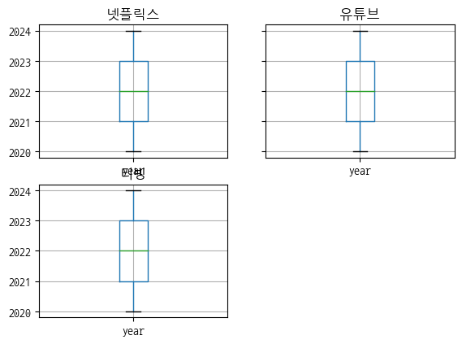

```python
df.groupby('ott_type')[['year']].boxplot()
plt.ylim(2015, 2030)
plt.show()
```

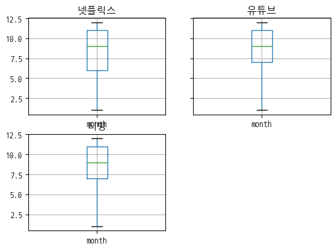

```python
df.groupby('ott_type')[['month']].boxplot()
plt.ylim(0, 13)
plt.show()
```

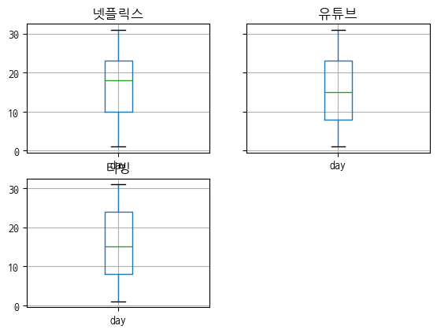

```python
df.groupby('ott_type')[['day']].boxplot()
plt.ylim(0, 32)
plt.show()
```

#### Statistics

##### One-sample T-test

Year

```python
year_expected_pop_mean = 2022
year_result = stats.ttest_1samp(df['year'], year_expected_pop_mean, alternative='greater')
print(year_result)
```

```
TtestResult(statistic=1.6298528848115748, pvalue=0.05160393393366466, df=4184)
```

```python
year_result = stats.ttest_1samp(df['year'], year_expected_pop_mean, alternative='less')
print(year_result)
```

```
TtestResult(statistic=1.6298528848115748, pvalue=0.9483960660663353, df=4184)
```

```python
year_result = stats.ttest_1samp(df['year'], year_expected_pop_mean, alternative='two-sided')
print(year_result)
```

```
TtestResult(statistic=1.6298528848115748, pvalue=0.10320786786732931, df=4184)
```

```python
(2023 - year_expected_pop_mean) / (df['year'].std() / math.sqrt(10))
```

```
2.331632494659503
```

Month

```python
month_mean = 9
month_result = stats.ttest_1samp(df['month'], month_mean)
print(month_result)
```

```
TtestResult(statistic=-9.463574147327776, pvalue=4.824074952180738e-21, df=4184)
```

```python
month_result = stats.ttest_1samp(df['month'], month_mean, alternative='greater')
print(month_result)
```

```
TtestResult(statistic=-9.463574147327776, pvalue=1.0, df=4184)
```

```python
month_result = stats.ttest_1samp(df['month'], month_mean, alternative='less')
print(month_result)
```

```
TtestResult(statistic=-9.463574147327776, pvalue=2.412037476090369e-21, df=4184)
```

```python
(3 - month_mean) / (df['month'].std() / math.sqrt(10))
```

```
-6.399964151610963
```

Day

```python
day_mean = 15
day_result = stats.ttest_1samp(df['day'], day_mean)
print(day_result)
```

```
TtestResult(statistic=7.89959128173246, pvalue=3.5491917281000692e-15, df=4184)
```

```python
day_result = stats.ttest_1samp(df['day'], day_mean, alternative='greater')
print(day_result)
```

```
TtestResult(statistic=7.89959128173246, pvalue=1.7745958640500346e-15, df=4184)
```

```python
day_result = stats.ttest_1samp(df['day'], day_mean, alternative='less')
print(day_result)
```

```
TtestResult(statistic=7.89959128173246, pvalue=0.9999999999999982, df=4184)
```

```python
(31 - day_mean) / (df['day'].std() / math.sqrt(10))
```

```
5.811790221561313
```

```python
df_2022_less = df[df['year'] < year_expected_pop_mean]
df_2022_greater = df[df['year'] >= year_expected_pop_mean]
```

```python
df_2022_greater['label'].value_counts()
```

```
label
1    2181
0     389
Name: count, dtype: int64
```

```python
df_2022_less['label'].value_counts()
```

```
label
1    1339
0     276
Name: count, dtype: int64
```

##### Independent T-test

Year

```python
result = stats.ttest_ind(df[df['label']==0]['year'], df[df['label']==1]['year'])
result
```

```
Ttest_indResult(statistic=-3.9890248187489936, pvalue=6.747986699380498e-05)
```

```python
result = stats.ttest_ind(df[df['label']==0]['year'], df[df['label']==1]['year'], alternative='greater')
result
```

```
Ttest_indResult(statistic=-3.9890248187489936, pvalue=0.9999662600665031)
```

```python
result = stats.ttest_ind(df[df['label']==0]['year'], df[df['label']==1]['year'], alternative='less')
result
```

```
Ttest_indResult(statistic=-3.9890248187489936, pvalue=3.373993349690249e-05)
```

month

```python
result = stats.ttest_ind(df[df['label']==0]['month'], df[df['label']==1]['month'])
result
```

```
Ttest_indResult(statistic=-1.449176268518037, pvalue=0.14736332391147433)
```

```python
result = stats.ttest_ind(df[df['label']==0]['month'], df[df['label']==1]['month'], alternative='greater')
result
```

```
Ttest_indResult(statistic=-1.449176268518037, pvalue=0.9263183380442628)
```

```python
result = stats.ttest_ind(df[df['label']==0]['month'], df[df['label']==1]['month'], alternative='less')
result
```

```
Ttest_indResult(statistic=-1.449176268518037, pvalue=0.07368166195573717)
```

Day

```python
result = stats.ttest_ind(df[df['label']==0]['day'], df[df['label']==1]['day'])
result
```

```
Ttest_indResult(statistic=-0.03860655362985255, pvalue=0.9692059194617861)
```

```python
result = stats.ttest_ind(df[df['label']==0]['day'], df[df['label']==1]['day'], alternative='greater')
result
```

```
Ttest_indResult(statistic=-0.03860655362985255, pvalue=0.5153970402691068)
```

```python
result = stats.ttest_ind(df[df['label']==0]['day'], df[df['label']==1]['day'], alternative='less')
result
```

```
Ttest_indResult(statistic=-0.03860655362985255, pvalue=0.48460295973089307)
```

### Data Augmentation

```python
df['label'].value_counts()
```

```
label
1    3520
0     665
Name: count, dtype: int64
```

#### SMOTE로 이용한 Data Augmentation

```python
# label에 대해서 SMOTE로 resample
smote = SMOTE(k_neighbors=2)
smote_scaled_df_oversampled_X, smote_scaled_df_oversampled_y = smote.fit_resample(
    df[['year', 'month', 'day']],
    df['label']
)

smote_oversampled_df = pd.concat([smote_scaled_df_oversampled_X, smote_scaled_df_oversampled_y], axis=1)
smote_oversampled_df.head()
```

|  | year | month | day | label |
| --- | --- | --- | --- | --- |
| 0 | 2020 | 6 | 5 | 1 |
| 1 | 2020 | 12 | 15 | 1 |
| 2 | 2020 | 3 | 22 | 1 |
| 3 | 2020 | 1 | 28 | 0 |
| 4 | 2020 | 12 | 31 | 1 |

```python
smote_oversampled_df['label'].value_counts()
```

```
label
1    3520
0    3520
Name: count, dtype: int64
```

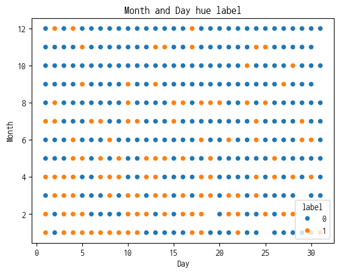

```python
sns.scatterplot(x='day', y='month', data=smote_oversampled_df, hue='label')
plt.xlabel('Day')
plt.ylabel('Month')
plt.title('Month and Day hue label')
plt.show()
```

```python
smote_X_train, smote_X_test, smote_y_train, smote_y_test = train_test_split(smote_scaled_df_oversampled_X, smote_scaled_df_oversampled_y, test_size=0.33, random_state=42)
min_max = MinMaxScaler()
smote_X_train = min_max.fit_transform(smote_X_train)
```

```
Metrics 출력
Accuracy Score 0.5098967297762479
Precision Score 0.5098967297762479
Recall Score 1.0
F1 Score 0.6754060986035909
ROC AUC Score 0.5
TPR 1.0
FPR 1.0
------------------------------------------------------------------
```

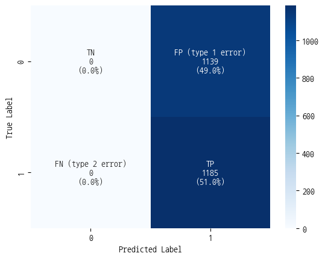

```python
lgc = LogisticRegression(random_state=42)
lgc.fit(smote_X_train, smote_y_train)
pred_y = lgc.predict(smote_X_test)
cf_matrix = confusion_matrix(smote_y_test.values, pred_y)

# annotation 준비
group_names = ["TN", "FP (type 1 error)", "FN (type 2 error)", "TP"]
group_counts = [value for value in cf_matrix.flatten()]
group_percentages = [f"{value:.1%}" for value in cf_matrix.flatten()/np.sum(cf_matrix)]
labels = [f"{v1}\n{v2}\n({v3})" for v1, v2, v3 in zip(group_names,group_counts,group_percentages)]
labels = np.asarray(labels).reshape(2,2)

# Metrics 출력
print("Metrics 출력")
print("Accuracy Score", accuracy_score(smote_y_test, pred_y))
print("Precision Score", precision_score(smote_y_test, pred_y))
print("Recall Score", recall_score(smote_y_test, pred_y))
print("F1 Score", f1_score(smote_y_test, pred_y))
print("ROC AUC Score", roc_auc_score(smote_y_test, pred_y))
TN, FP, FN, TP = cf_matrix.ravel()
TPR = TP / (TP+FN)
FPR = FP / (FP+TN)
print("TPR", TPR)
print("FPR", FPR)
print("------------------------------------------------------------------")

# Confusion Matrix 시각화
sns.heatmap(cf_matrix, annot=labels, fmt='', cmap='Blues')
plt.xlabel('Predicted Label')
plt.ylabel('True Label')
```

```python
dtc = DecisionTreeClassifier()
dtc.fit(smote_X_train, smote_y_train)
pred_y = dtc.predict(smote_X_test)
cf_matrix = confusion_matrix(smote_y_test.values, pred_y)

# annotation 준비
group_names = ["TN", "FP (type 1 error)", "FN (type 2 error)", "TP"]
group_counts = [value for value in cf_matrix.flatten()]
group_percentages = [f"{value:.1%}" for value in cf_matrix.flatten()/np.sum(cf_matrix)]
labels = [f"{v1}\n{v2}\n({v3})" for v1, v2, v3 in zip(group_names,group_counts,group_percentages)]
labels = np.asarray(labels).reshape(2,2)

# Metrics 출력
print("Metrics 출력")
print("Accuracy Score", accuracy_score(smote_y_test, pred_y))
print("Precision Score", precision_score(smote_y_test, pred_y))
print("Recall Score", recall_score(smote_y_test, pred_y))
print("F1 Score", f1_score(smote_y_test, pred_y))
print("ROC AUC Score", roc_auc_score(smote_y_test, pred_y))
TN, FP, FN, TP = cf_matrix.ravel()
TPR = TP / (TP+FN)
FPR = FP / (FP+TN)
print("TPR", TPR)
print("FPR", FPR)
print("------------------------------------------------------------------")

# Confusion Matrix 시각화
sns.heatmap(cf_matrix, annot=labels, fmt='', cmap='Blues')
plt.xlabel('Predicted Label')
plt.ylabel('True Label')
```

[output not shown]

```
Metrics 출력
Accuracy Score 0.49010327022375216
Precision Score 0.0
Recall Score 0.0
F1 Score 0.0
ROC AUC Score 0.5
TPR 0.0
FPR 0.0
------------------------------------------------------------------
```

```
Metrics 출력
Accuracy Score 0.5098967297762479
Precision Score 0.5098967297762479
Recall Score 1.0
F1 Score 0.6754060986035909
ROC AUC Score 0.5
TPR 1.0
FPR 1.0
------------------------------------------------------------------
```

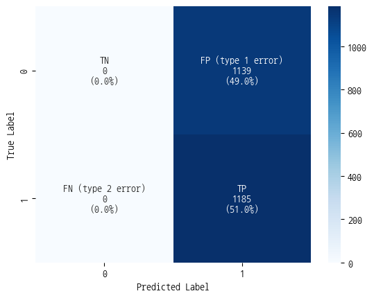

```python
svc = SVC(kernel='linear')
svc.fit(smote_X_train, smote_y_train)
pred_y = svc.predict(smote_X_test)
cf_matrix = confusion_matrix(smote_y_test.values, pred_y)

# annotation 준비
group_names = ["TN", "FP (type 1 error)", "FN (type 2 error)", "TP"]
group_counts = [value for value in cf_matrix.flatten()]
group_percentages = [f"{value:.1%}" for value in cf_matrix.flatten()/np.sum(cf_matrix)]
labels = [f"{v1}\n{v2}\n({v3})" for v1, v2, v3 in zip(group_names,group_counts,group_percentages)]
labels = np.asarray(labels).reshape(2,2)

# Metrics 출력
print("Metrics 출력")
print("Accuracy Score", accuracy_score(smote_y_test, pred_y))
print("Precision Score", precision_score(smote_y_test, pred_y))
print("Recall Score", recall_score(smote_y_test, pred_y))
print("F1 Score", f1_score(smote_y_test, pred_y))
print("ROC AUC Score", roc_auc_score(smote_y_test, pred_y))
TN, FP, FN, TP = cf_matrix.ravel()
TPR = TP / (TP+FN)
FPR = FP / (FP+TN)
print("TPR", TPR)
print("FPR", FPR)
print("------------------------------------------------------------------")

# Confusion Matrix 시각화
sns.heatmap(cf_matrix, annot=labels, fmt='', cmap='Blues')
plt.xlabel('Predicted Label')
plt.ylabel('True Label')
```

```python
rfc = RandomForestClassifier(random_state=42)
rfc.fit(smote_X_train, smote_y_train)
pred_y = rfc.predict(smote_X_test)
cf_matrix = confusion_matrix(smote_y_test.values, pred_y)

# annotation 준비
group_names = ["TN", "FP (type 1 error)", "FN (type 2 error)", "TP"]
group_counts = [value for value in cf_matrix.flatten()]
group_percentages = [f"{value:.1%}" for value in cf_matrix.flatten()/np.sum(cf_matrix)]
labels = [f"{v1}\n{v2}\n({v3})" for v1, v2, v3 in zip(group_names,group_counts,group_percentages)]
labels = np.asarray(labels).reshape(2,2)

# Metrics 출력
print("Metrics 출력")
print("Accuracy Score", accuracy_score(smote_y_test, pred_y))
print("Precision Score", precision_score(smote_y_test, pred_y))
print("Recall Score", recall_score(smote_y_test, pred_y))
print("F1 Score", f1_score(smote_y_test, pred_y))
print("ROC AUC Score", roc_auc_score(smote_y_test, pred_y))
TN, FP, FN, TP = cf_matrix.ravel()
TPR = TP / (TP+FN)
FPR = FP / (FP+TN)
print("TPR", TPR)
print("FPR", FPR)
print("------------------------------------------------------------------")

# Confusion Matrix 시각화
sns.heatmap(cf_matrix, annot=labels, fmt='', cmap='Blues')
plt.xlabel('Predicted Label')
plt.ylabel('True Label')
```

```
Metrics 출력
Accuracy Score 0.49010327022375216
Precision Score 0.0
Recall Score 0.0
F1 Score 0.0
ROC AUC Score 0.5
TPR 0.0
FPR 0.0
------------------------------------------------------------------
```

```python
bagc = BaggingClassifier()
bagc.fit(smote_X_train, smote_y_train)
pred_y = bagc.predict(smote_X_test)
cf_matrix = confusion_matrix(smote_y_test.values, pred_y)

# annotation 준비
group_names = ["TN", "FP (type 1 error)", "FN (type 2 error)", "TP"]
group_counts = [value for value in cf_matrix.flatten()]
group_percentages = [f"{value:.1%}" for value in cf_matrix.flatten()/np.sum(cf_matrix)]
labels = [f"{v1}\n{v2}\n({v3})" for v1, v2, v3 in zip(group_names,group_counts,group_percentages)]
labels = np.asarray(labels).reshape(2,2)

# Metrics 출력
print("Metrics 출력")
print("Accuracy Score", accuracy_score(smote_y_test, pred_y))
print("Precision Score", precision_score(smote_y_test, pred_y))
print("Recall Score", recall_score(smote_y_test, pred_y))
print("F1 Score", f1_score(smote_y_test, pred_y))
print("ROC AUC Score", roc_auc_score(smote_y_test, pred_y))
TN, FP, FN, TP = cf_matrix.ravel()
TPR = TP / (TP+FN)
FPR = FP / (FP+TN)
print("TPR", TPR)
print("FPR", FPR)
print("------------------------------------------------------------------")

# Confusion Matrix 시각화
sns.heatmap(cf_matrix, annot=labels, fmt='', cmap='Blues')
plt.xlabel('Predicted Label')
plt.ylabel('True Label')
```

```
Metrics 출력
Accuracy Score 0.49010327022375216
Precision Score 0.0
Recall Score 0.0
F1 Score 0.0
ROC AUC Score 0.5
TPR 0.0
FPR 0.0
------------------------------------------------------------------
```

```python
navie_bayes = GaussianNB()
navie_bayes.fit(smote_X_train, smote_y_train)
pred_y = navie_bayes.predict(smote_X_test)
cf_matrix = confusion_matrix(smote_y_test.values, pred_y)

# annotation 준비
group_names = ["TN", "FP (type 1 error)", "FN (type 2 error)", "TP"]
group_counts = [value for value in cf_matrix.flatten()]
group_percentages = [f"{value:.1%}" for value in cf_matrix.flatten()/np.sum(cf_matrix)]
labels = [f"{v1}\n{v2}\n({v3})" for v1, v2, v3 in zip(group_names,group_counts,group_percentages)]
labels = np.asarray(labels).reshape(2,2)

# Metrics 출력
print("Metrics 출력")
print("Accuracy Score", accuracy_score(smote_y_test, pred_y))
print("Precision Score", precision_score(smote_y_test, pred_y))
print("Recall Score", recall_score(smote_y_test, pred_y))
print("F1 Score", f1_score(smote_y_test, pred_y))
print("ROC AUC Score", roc_auc_score(smote_y_test, pred_y))
TN, FP, FN, TP = confusion_matrix(smote_y_test.values, pred_y).ravel()
TPR = TP / (TP+FN)
FPR = FP / (FP+TN)
print("TPR", TPR)
print("FPR", FPR)
print("------------------------------------------------------------------")

# Confusion Matrix 시각화
sns.heatmap(cf_matrix, annot=labels, fmt='', cmap='Blues')
plt.xlabel('Predicted Label')
plt.ylabel('True Label')
```

```
Metrics 출력
Accuracy Score 0.49010327022375216
Precision Score 0.0
Recall Score 0.0
F1 Score 0.0
ROC AUC Score 0.5
TPR 0.0
FPR 0.0
------------------------------------------------------------------
```

```python
clf1 = LogisticRegression(random_state=42)
clf2 = RandomForestClassifier(random_state=42)
clf3 = GaussianNB()
clf4 = SVC(kernel='linear', probability=True)  # soft voting을 위해선 probability=True 필요
clf5 = KNeighborsClassifier()

voting_clf = VotingClassifier(
    estimators=[
        ('log_reg', clf1),
        ('ran_fst', clf2),
        ('gau_nb', clf3),
        ('svc', clf4),
        ('knn', clf5)
    ],
    voting='hard'  # 또는 'soft'
)
voting_clf.fit(smote_X_train, smote_y_train)
pred_y = voting_clf.predict(smote_X_test)
cf_matrix = confusion_matrix(smote_y_test.values, pred_y)

# annotation 준비
group_names = ["TN", "FP (type 1 error)", "FN (type 2 error)", "TP"]
group_counts = [value for value in cf_matrix.flatten()]
group_percentages = [f"{value:.1%}" for value in cf_matrix.flatten()/np.sum(cf_matrix)]
labels = [f"{v1}\n{v2}\n({v3})" for v1, v2, v3 in zip(group_names,group_counts,group_percentages)]
labels = np.asarray(labels).reshape(2,2)

# Metrics 출력
print("Metrics 출력")
print("Accuracy Score", accuracy_score(smote_y_test, pred_y))
print("Precision Score", precision_score(smote_y_test, pred_y))
print("Recall Score", recall_score(smote_y_test, pred_y))
print("F1 Score", f1_score(smote_y_test, pred_y))
print("ROC AUC Score", roc_auc_score(smote_y_test, pred_y))
TN, FP, FN, TP = confusion_matrix(smote_y_test.values, pred_y).ravel()
TPR = TP / (TP+FN)
FPR = FP / (FP+TN)
print("TPR", TPR)
print("FPR", FPR)
print("------------------------------------------------------------------")

# Confusion Matrix 시각화
sns.heatmap(cf_matrix, annot=labels, fmt='', cmap='Blues')
plt.xlabel('Predicted Label')
plt.ylabel('True Label')
```

```
Metrics 출력
Accuracy Score 0.49010327022375216
Precision Score 0.0
Recall Score 0.0
F1 Score 0.0
ROC AUC Score 0.5
TPR 0.0
FPR 0.0
------------------------------------------------------------------
```

### 가설2: OTT에서 언급된 OTT와 뉴스 제목 및 뉴스 내용에 언급된 OTT가 사용된 키워드 빈도에 따라 OTT가 긍정적인지 부정적인지가 달라진다.(군집화, T-test)

우선 뉴스 제목에 대해서 불필요한 것을 제거한다.(Cleaning)

```python
df_title_series = df['title']
df_title_series.head()
```

```
0      넷플릭스로 알아보는 MSA | 인사이트리포트 | 삼성SDS
1        넷플릭스, AI 시스템으로 얼마만큼 흥행할 지 예상한다
2             넷플릭스, 한국 최고의 스토리 한자리에 모으다
3    한국 넷플릭스에선 볼 수 있는 토토로, 美·日선 못 본다 왜?
4                      # 나의 넷플릭스 시청 연대기
Name: title, dtype: object
```

```python
def clean_attribute_title(title):
    if pd.isna(title):
        return ""
    # 1. 반점, 느낌표, 물음표 제거
    title = re.sub(r'[,!?]', '', title)
    # 2. 한글과 공백만 남기고 모두 제거
    cleaned = re.sub(r'[^가-힣\s]', '', title)
    # 3. 불필요한 공백 정리
    cleaned = re.sub(r'\s+', ' ', cleaned).strip()
    return cleaned
df['title_fix'] = df['title'].apply(clean_attribute_title)
df['title_fix'].head()
```

```
0            넷플릭스로 알아보는 인사이트리포트 삼성
1       넷플릭스 시스템으로 얼마만큼 흥행할 지 예상한다
2         넷플릭스 한국 최고의 스토리 한자리에 모으다
3    한국 넷플릭스에선 볼 수 있는 토토로 선 못 본다 왜
4                   나의 넷플릭스 시청 연대기
Name: title_fix, dtype: object
```

```python
# 문자열로 변환 후 ott_type의 등장 횟수를 세어 새로운 열에 저장
df['title_ott_keyword'] = df.apply(
    lambda row: str(row['title_fix']).count(str(row['ott_type'])) if row['ott_type'] else 0,
    axis=1
)
```

```python
df[['title', 'title_ott_keyword']].head()
```

|  | title | title_ott_keyword |
| --- | --- | --- |
| 0 | 넷플릭스로 알아보는 MSA \| 인사이트리포트 \| 삼성SDS | 1 |
| 1 | 넷플릭스, AI 시스템으로 얼마만큼 흥행할 지 예상한다 | 1 |
| 2 | 넷플릭스, 한국 최고의 스토리 한자리에 모으다 | 1 |
| 3 | 한국 넷플릭스에선 볼 수 있는 토토로, 美·日선 못 본다 왜? | 1 |
| 4 | # 나의 넷플릭스 시청 연대기 | 1 |

```python
df['title_ott_keyword'].value_counts()
```

```
title_ott_keyword
1    3878
0     215
2      91
3       1
Name: count, dtype: int64
```

뉴스 content의 경우 뉴스 content에 대해서 불필요한 것을 제거한다.(Cleaning)

```python
df['comment_fix'] = df['comment'].apply(clean_attribute_title)
df['comment_fix'].head()
```

```
0    개발자가 폴백 메소드를 구현함으로써 시스템 장애로부터 유연하게 복구를 실행할 수 있...
1    넷플릭스는 영화드라마 주제를 비교하기 위해 가 영상 메타데이터설명데이터 키워드 요약...
2    넷플릭스 한국 최고의 스토리 한자리에 모으다 한국아시아 태평양 지역모든 영어권 국가...
3    지브리 명작 편 넷플릭스로 본다 오는 월부터 한국 포함 약 개국 넷플릭스에서 이웃집...
4    나의 넷플릭스 시청 연대기 간만 보려 했다가 카운터 펀치를 당하다 하우스 오브 카드...
Name: comment_fix, dtype: object
```

```python
# 문자열로 변환 후 ott_type의 등장 횟수를 세어 새로운 열에 저장
df['comment_ott_keyword'] = df.apply(
    lambda row: str(row['comment_fix']).count(str(row['ott_type'])) if row['ott_type'] else 0,
    axis=1
)
df['comment_ott_keyword'].value_counts()
```

```
comment_ott_keyword
1    1811
0    1209
2     952
3     188
4      23
5       2
Name: count, dtype: int64
```

#### K-means k 값에 따른 군집화

```python
kmeans = KMeans(n_clusters=2, random_state=42)
kmeans.fit(df[['title_ott_keyword', 'comment_ott_keyword']])
df['k_means_n_clusters_2'] = kmeans.predict(df[['title_ott_keyword', 'comment_ott_keyword']])  # or it is also possible to fit and predict at once, using fit_predict()
```

[output not shown]

```python
print("- Cluster_centers:")
for x, y in kmeans.cluster_centers_:
    print("\tcenter x and y:", x, y)
print("- Labels:", kmeans.labels_)
print("- n_iter:", kmeans.n_iter_)
print("- inertia:", kmeans.inertia_)

score1 = silhouette_score(df[['title_ott_keyword', 'comment_ott_keyword']], df['k_means_n_clusters_2'])
print("2 Clusters:", score1)

print("Homogenity: ", homogeneity_score(df['label'], df['k_means_n_clusters_2']))
print("Completeness: ", completeness_score(df['label'], df['k_means_n_clusters_2']))
print("V-measure: ", v_measure_score(df['label'], df['k_means_n_clusters_2']))
```

```
- Cluster_centers:
	center x and y: 0.9500000000000002 0.5996688741721861
	center x and y: 1.024892703862661 2.2060085836909877
- Labels: [0 1 0 ... 0 0 1]
- n_iter: 2
- inertia: 1275.2857203763183
2 Clusters: 0.6739567554015065
Homogenity:  0.00012390150577456933
Completeness:  9.172853669957898e-05
V-measure:  0.00010541484562326937
```

```python
kmeans = KMeans(n_clusters=3, random_state=42)
kmeans.fit(df[['title_ott_keyword', 'comment_ott_keyword']])
df['k_means_n_clusters_3'] = kmeans.predict(df[['title_ott_keyword', 'comment_ott_keyword']])  # or it is also possible to fit and predict at once, using fit_predict()
```

```python
print("- Cluster_centers:")
for x, y in kmeans.cluster_centers_:
    print("\tcenter x and y:", x, y)
print("- Labels:", kmeans.labels_)
print("- n_iter:", kmeans.n_iter_)
print("- inertia:", kmeans.inertia_)

score1 = silhouette_score(df[['title_ott_keyword', 'comment_ott_keyword']], df['k_means_n_clusters_3'])
print("3 Clusters:", score1)

print("Homogenity: ", homogeneity_score(df['label'], df['k_means_n_clusters_3']))
print("Completeness: ", completeness_score(df['label'], df['k_means_n_clusters_3']))
print("V-measure: ", v_measure_score(df['label'], df['k_means_n_clusters_3']))
```

```
- Cluster_centers:
	center x and y: 0.9081885856079406 2.220446049250313e-16
	center x and y: 1.024892703862661 2.2060085836909877
	center x and y: 0.9779127553837659 1.0
- Labels: [0 1 2 ... 0 2 1]
- n_iter: 2
- inertia: 546.7614947199785
3 Clusters: 0.8259870968837469
Homogenity:  0.0040958115085068855
Completeness:  0.0016648438594658334
V-measure:  0.002367399611293488
```

```python
kmeans = KMeans(n_clusters=4, random_state=42)
kmeans.fit(df[['title_ott_keyword', 'comment_ott_keyword']])
df['k_means_n_clusters_4'] = kmeans.predict(df[['title_ott_keyword', 'comment_ott_keyword']])  # or it is also possible to fit and predict at once, using fit_predict()
```

```python
print("- Cluster_centers:")
for x, y in kmeans.cluster_centers_:
    print("\tcenter x and y:", x, y)
print("- Labels:", kmeans.labels_)
print("- n_iter:", kmeans.n_iter_)
print("- inertia:", kmeans.inertia_)

score1 = silhouette_score(df[['title_ott_keyword', 'comment_ott_keyword']], df['k_means_n_clusters_4'])
print("4 Clusters:", score1)

print("Homogenity: ", homogeneity_score(df['label'], df['k_means_n_clusters_4']))
print("Completeness: ", completeness_score(df['label'], df['k_means_n_clusters_4']))
print("V-measure: ", v_measure_score(df['label'], df['k_means_n_clusters_4']))
```

```
- Cluster_centers:
	center x and y: 1.0063025210084033 1.9999999999999996
	center x and y: 0.9779127553837659 1.0
	center x and y: 0.9081885856079406 4.440892098500626e-16
	center x and y: 1.107981220657277 3.1267605633802815
- Labels: [2 0 1 ... 2 1 0]
- n_iter: 2
- inertia: 323.9815248053967
4 Clusters: 0.8776525389202935
Homogenity:  0.004121241176831357
Completeness:  0.0014917993367631372
V-measure:  0.002190636194179484
```

```python
kmeans = KMeans(n_clusters=5, random_state=42)
kmeans.fit(df[['title_ott_keyword', 'comment_ott_keyword']])
df['k_means_n_clusters_5'] = kmeans.predict(df[['title_ott_keyword', 'comment_ott_keyword']])  # or it is also possible to fit and predict at once, using fit_predict()
```

```python
print("- Cluster_centers:")
for x, y in kmeans.cluster_centers_:
    print("\tcenter x and y:", x, y)
print("- Labels:", kmeans.labels_)
print("- n_iter:", kmeans.n_iter_)
print("- inertia:", kmeans.inertia_)

score1 = silhouette_score(df[['title_ott_keyword', 'comment_ott_keyword']], df['k_means_n_clusters_5'])
print("5 Clusters:", score1)

print("Homogenity: ", homogeneity_score(df['label'], df['k_means_n_clusters_5']))
print("Completeness: ", completeness_score(df['label'], df['k_means_n_clusters_5']))
print("V-measure: ", v_measure_score(df['label'], df['k_means_n_clusters_5']))
```

```
- Cluster_centers:
	center x and y: 1.011049723756906 2.220446049250313e-16
	center x and y: 1.0063025210084033 1.9999999999999996
	center x and y: 1.0166475315729047 1.0
	center x and y: 9.992007221626409e-16 0.3593749999999998
	center x and y: 1.107981220657277 3.126760563380281
- Labels: [0 1 2 ... 0 2 1]
- n_iter: 2
- inertia: 186.6438314868676
5 Clusters: 0.9275629126598129
Homogenity:  0.010341253409920733
Completeness:  0.003367238656513273
V-measure:  0.005080276965538327
```

k_means k=2일 때 시각화

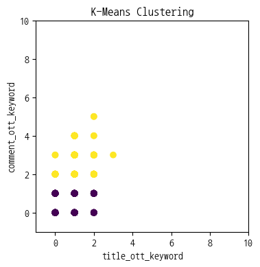

```python
plt.figure(figsize=(4, 4))
plt.scatter(df['title_ott_keyword'], df['comment_ott_keyword'], c=df['k_means_n_clusters_2'], marker='o')
plt.title("K-Means Clustering")
plt.xlabel("title_ott_keyword")
plt.ylabel("comment_ott_keyword")
plt.xlim([-1, 10])
plt.ylim([-1, 10])
plt.show()
```

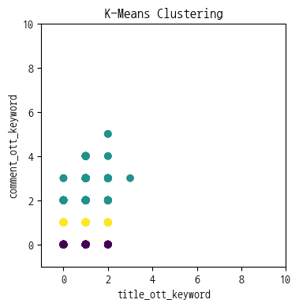

```python
plt.figure(figsize=(4, 4))
plt.scatter(df['title_ott_keyword'], df['comment_ott_keyword'], c=df['k_means_n_clusters_3'], marker='o')
plt.title("K-Means Clustering")
plt.xlabel("title_ott_keyword")
plt.ylabel("comment_ott_keyword")
plt.xlim([-1, 10])
plt.ylim([-1, 10])
plt.show()
```

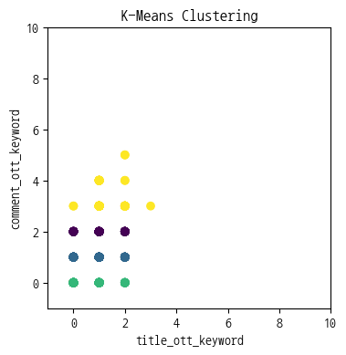

```python
plt.figure(figsize=(4, 4))
plt.scatter(df['title_ott_keyword'], df['comment_ott_keyword'], c=df['k_means_n_clusters_4'], marker='o')
plt.title("K-Means Clustering")
plt.xlabel("title_ott_keyword")
plt.ylabel("comment_ott_keyword")
plt.xlim([-1, 10])
plt.ylim([-1, 10])
plt.show()
```

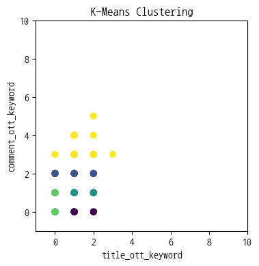

```python
plt.figure(figsize=(4, 4))
plt.scatter(df['title_ott_keyword'], df['comment_ott_keyword'], c=df['k_means_n_clusters_5'], marker='o')
plt.title("K-Means Clustering")
plt.xlabel("title_ott_keyword")
plt.ylabel("comment_ott_keyword")
plt.xlim([-1, 10])
plt.ylim([-1, 10])
plt.show()
```

#### DBSCAN 군집화

```python
dbscan_params = [(0.1, 3), (0.2, 2), (0.3, 2), (0.15, 3), (0.25, 2), (0.2, 3)]  # (eps, minPts) pairs

dbscan_labels = {}
for i, (eps, MinPts) in enumerate(dbscan_params, 1):
    dbscan = DBSCAN(eps=eps, min_samples=MinPts)
    df[f'dbscan_cluster_{i}'] = dbscan.fit_predict(df[['title_ott_keyword', 'comment_ott_keyword']])
    dbscan_labels[i] = df[f'dbscan_cluster_{i}'].values
    print("- Labels:", dbscan.labels_)
    print("Homogenity: ", homogeneity_score(df['label'], df[f'dbscan_cluster_{i}']))
    print("Completeness: ", completeness_score(df['label'], df[f'dbscan_cluster_{i}']))
    print("V-measure: ", v_measure_score(df['label'], df[f'dbscan_cluster_{i}']))
    score1 = silhouette_score(df[['title_ott_keyword', 'comment_ott_keyword']], df[f'dbscan_cluster_{i}'])
    print("DBSCAN Sihouette Score:", score1)
```

```
- Labels: [0 1 2 ... 0 2 1]
Homogenity:  0.02170473130147202
Completeness:  0.006263862239320103
V-measure:  0.009722008124261878
DBSCAN Sihouette Score: 0.9977543985136905
- Labels: [0 1 2 ... 0 2 1]
Homogenity:  0.02251489434073767
Completeness:  0.006488001494756289
V-measure:  0.010073247096809982
DBSCAN Sihouette Score: 0.9997610513739545
- Labels: [0 1 2 ... 0 2 1]
Homogenity:  0.02251489434073767
Completeness:  0.006488001494756289
V-measure:  0.010073247096809982
DBSCAN Sihouette Score: 0.9997610513739545
- Labels: [0 1 2 ... 0 2 1]
Homogenity:  0.02170473130147202
Completeness:  0.006263862239320103
V-measure:  0.009722008124261878
DBSCAN Sihouette Score: 0.9977543985136905
- Labels: [0 1 2 ... 0 2 1]
Homogenity:  0.02251489434073767
Completeness:  0.006488001494756289
V-measure:  0.010073247096809982
DBSCAN Sihouette Score: 0.9997610513739545
- Labels: [0 1 2 ... 0 2 1]
Homogenity:  0.02170473130147202
Completeness:  0.006263862239320103
V-measure:  0.009722008124261878
DBSCAN Sihouette Score: 0.9977543985136905
```

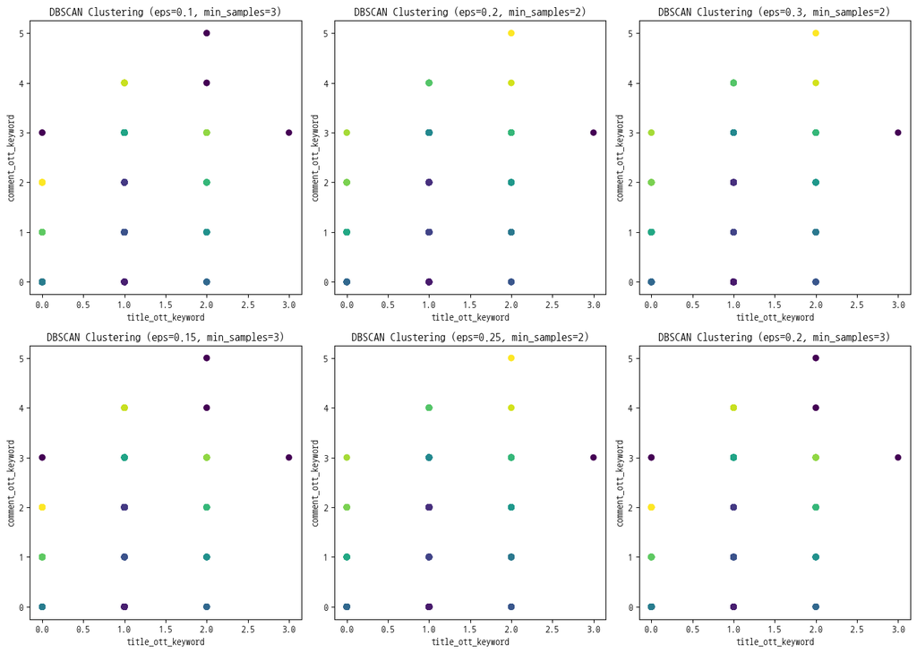

```python
fig, axes = plt.subplots(2, 3, figsize=(14, 10))
axes = axes.flatten()

for i, ax in enumerate(axes, 1):
    ax.scatter(df['title_ott_keyword'], df['comment_ott_keyword'], c=dbscan_labels[i], marker='o')
    eps, min_samples = dbscan_params[i-1]
    ax.set_title(f"DBSCAN Clustering (eps={eps}, min_samples={min_samples})")
    ax.set_xlabel("title_ott_keyword")
    ax.set_ylabel("comment_ott_keyword")

plt.tight_layout()
plt.show()
```

### Statistics

제목, 내용에 언급되는 ott_type 수에 따라 ott_type, label이 어떤지가 달라진다.(One Sample T-test, Two-Sample T-test)

##### title

```python
title_ott_keyword_pop_mean = 1
title_ott_result = stats.ttest_1samp(df['title_ott_keyword'], title_ott_keyword_pop_mean)
print(title_ott_result)
```

```
TtestResult(statistic=-6.968394647884603, pvalue=3.7079618719055696e-12, df=4184)
```

```python
title_ott_keyword_pop_mean = 1
title_ott_result = stats.ttest_1samp(df['title_ott_keyword'], title_ott_keyword_pop_mean, alternative='greater')
print(title_ott_result)
```

```
TtestResult(statistic=-6.968394647884603, pvalue=0.999999999998146, df=4184)
```

```python
title_ott_keyword_pop_mean = 1
title_ott_result = stats.ttest_1samp(df['title_ott_keyword'], title_ott_keyword_pop_mean, alternative='less')
print(title_ott_result)
```

```
TtestResult(statistic=-6.968394647884603, pvalue=1.8539809359527848e-12, df=4184)
```

##### comment

```python
comment_ott_keyword_pop_mean = 1
comment_ott_result = stats.ttest_1samp(df['comment_ott_keyword'], comment_ott_keyword_pop_mean)
print(comment_ott_result)
```

```
TtestResult(statistic=3.4957823559414414, pvalue=0.0004775815718725659, df=4184)
```

```python
comment_ott_keyword_pop_mean = 1
comment_ott_result = stats.ttest_1samp(df['comment_ott_keyword'], comment_ott_keyword_pop_mean, alternative='greater')
print(title_ott_result)
```

```
TtestResult(statistic=-6.968394647884603, pvalue=1.8539809359527848e-12, df=4184)
```

```python
comment_ott_keyword_pop_mean = 1
comment_ott_result = stats.ttest_1samp(df['comment_ott_keyword'], comment_ott_keyword_pop_mean, alternative='less')
print(title_ott_result)
```

```
TtestResult(statistic=-6.968394647884603, pvalue=1.8539809359527848e-12, df=4184)
```

##### Two-sample Independent T-test

##### title

```python
result = stats.ttest_ind(df[df['label']==0]['title_ott_keyword'], df[df['label']==1]['title_ott_keyword'])
result
```

```
Ttest_indResult(statistic=-6.534010821485149, pvalue=7.170781511943918e-11)
```

```python
result = stats.ttest_ind(df[df['label']==0]['title_ott_keyword'], df[df['label']==1]['title_ott_keyword'], alternative='greater')
result
```

```
Ttest_indResult(statistic=-6.534010821485149, pvalue=0.9999999999641461)
```

```python
result = stats.ttest_ind(df[df['label']==0]['title_ott_keyword'], df[df['label']==1]['title_ott_keyword'], alternative='less')
result
```

```
Ttest_indResult(statistic=-6.534010821485149, pvalue=3.585390755971959e-11)
```

```python
df_title_two_greater = df[df['title_ott_keyword'] >= 2]
df_title_two_less = df[df['title_ott_keyword'] < 2]
```

##### comment

```python
content_ott_result = stats.ttest_ind(df[df['label'] == 0]['comment_ott_keyword'], df[df['label'] == 1]['comment_ott_keyword'])
print(content_ott_result)
```

```
Ttest_indResult(statistic=-2.350084558930389, pvalue=0.01881536424638781)
```

```python
content_ott_result = stats.ttest_ind(df[df['label'] == 0]['comment_ott_keyword'], df[df['label'] == 1]['comment_ott_keyword'], alternative='greater')
print(content_ott_result)
```

```
Ttest_indResult(statistic=-2.350084558930389, pvalue=0.9905923178768061)
```

```python
content_ott_result = stats.ttest_ind(df[df['label'] == 0]['comment_ott_keyword'], df[df['label'] == 1]['comment_ott_keyword'], alternative='less')
print(content_ott_result)
```

```
Ttest_indResult(statistic=-2.350084558930389, pvalue=0.009407682123193905)
```

```python
df_content_two_greater = df[df['comment_ott_keyword'] >= 2]
df_content_two_less = df[df['comment_ott_keyword'] < 2]
```

```python
df_content_two_greater['label'].value_counts()
```

```
label
1    987
0    178
Name: count, dtype: int64
```

```python
df_content_two_less['label'].value_counts()
```

```
label
1    2533
0     487
Name: count, dtype: int64
```

### 데이터 증강(Data Augmentation) 기법

```python
# label에 대해서 SMOTE로 resample
smote = SMOTE(k_neighbors=2)
smote_scaled_df_oversampled_X, smote_scaled_df_oversampled_y = smote.fit_resample(
    df[['title_ott_keyword', 'comment_ott_keyword']],
    df['label']
)

smote_oversampled_df = pd.concat([smote_scaled_df_oversampled_X, smote_scaled_df_oversampled_y], axis=1)
smote_oversampled_df.head()
```

|  | title_ott_keyword | comment_ott_keyword | label |
| --- | --- | --- | --- |
| 0 | 1 | 0 | 1 |
| 1 | 1 | 2 | 1 |
| 2 | 1 | 1 | 1 |
| 3 | 1 | 2 | 0 |
| 4 | 1 | 1 | 1 |

```python
smote_oversampled_df['label'].value_counts()
```

```
label
1    3520
0    3520
Name: count, dtype: int64
```

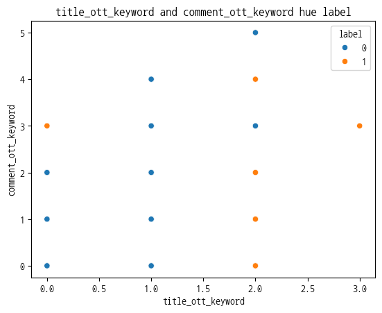

```python
sns.scatterplot(x='title_ott_keyword', y='comment_ott_keyword', data=smote_oversampled_df, hue='label')
plt.xlabel('title_ott_keyword')
plt.ylabel('comment_ott_keyword')
plt.title('title_ott_keyword and comment_ott_keyword hue label')
plt.show()
```

### K-means

k값에 따른 군집화

k = 2

```python
kmeans = KMeans(n_clusters=2, random_state=42)
kmeans.fit(smote_oversampled_df[['title_ott_keyword', 'comment_ott_keyword']])
smote_oversampled_df['k_means_n_clusters_2'] = kmeans.predict(smote_oversampled_df[['title_ott_keyword', 'comment_ott_keyword']])  # or it is also possible to fit and predict at once, using fit_predict()
```

```python
print("- Cluster_centers:")
for x, y in kmeans.cluster_centers_:
    print("\tcenter x and y:", x, y)
print("- Labels:", kmeans.labels_)
print("- n_iter:", kmeans.n_iter_)
print("- inertia:", kmeans.inertia_)

score1 = silhouette_score(smote_oversampled_df[['title_ott_keyword', 'comment_ott_keyword']], smote_oversampled_df['k_means_n_clusters_2'])
print("2 Clusters:", score1)

print("Homogenity: ", homogeneity_score(smote_oversampled_df['label'], smote_oversampled_df['k_means_n_clusters_2']))
print("Completeness: ", completeness_score(smote_oversampled_df['label'], smote_oversampled_df['k_means_n_clusters_2']))
print("V-measure: ", v_measure_score(smote_oversampled_df['label'], smote_oversampled_df['k_means_n_clusters_2']))
```

```
- Cluster_centers:
	center x and y: 0.9184278095990516 0.564487458028835
	center x and y: 1.0111279716742538 2.2058674759736965
- Labels: [0 1 0 ... 0 1 0]
- n_iter: 2
- inertia: 2194.9726522198584
2 Clusters: 0.6684011968909602
Homogenity:  6.485934877331094e-07
Completeness:  7.571976188501862e-07
V-measure:  6.987004572918011e-07
```

k = 3

```python
kmeans = KMeans(n_clusters=3, random_state=42)
kmeans.fit(smote_oversampled_df[['title_ott_keyword', 'comment_ott_keyword']])
smote_oversampled_df['k_means_n_clusters_3'] = kmeans.predict(smote_oversampled_df[['title_ott_keyword', 'comment_ott_keyword']])  # or it is also possible to fit and predict at once, using fit_predict()
```

```python
print("- Cluster_centers:")
for x, y in kmeans.cluster_centers_:
    print("\tcenter x and y:", x, y)
print("- Labels:", kmeans.labels_)
print("- n_iter:", kmeans.n_iter_)
print("- inertia:", kmeans.inertia_)

score1 = silhouette_score(smote_oversampled_df[['title_ott_keyword', 'comment_ott_keyword']], smote_oversampled_df['k_means_n_clusters_3'])
print("4 Clusters:", score1)

print("Homogenity: ", homogeneity_score(smote_oversampled_df['label'], smote_oversampled_df['k_means_n_clusters_3']))
print("Completeness: ", completeness_score(smote_oversampled_df['label'], smote_oversampled_df['k_means_n_clusters_3']))
print("V-measure: ", v_measure_score(smote_oversampled_df['label'], smote_oversampled_df['k_means_n_clusters_3']))
```

```
- Cluster_centers:
	center x and y: 0.8458049886621313 -1.1102230246251565e-15
	center x and y: 0.9744576627011896 1.0
	center x and y: 1.0111279716742538 2.205867475973696
- Labels: [0 2 1 ... 1 2 0]
- n_iter: 2
- inertia: 929.6762274241834
4 Clusters: 0.8142121220002089
Homogenity:  0.005334190027216795
Completeness:  0.003403874959061798
V-measure:  0.00415582074270042
```

k = 4

```python
kmeans = KMeans(n_clusters=4, random_state=42)
kmeans.fit(smote_oversampled_df[['title_ott_keyword', 'comment_ott_keyword']])
smote_oversampled_df['k_means_n_clusters_4'] = kmeans.predict(smote_oversampled_df[['title_ott_keyword', 'comment_ott_keyword']])  # or it is also possible to fit and predict at once, using fit_predict()
```

```python
print("- Cluster_centers:")
for x, y in kmeans.cluster_centers_:
    print("\tcenter x and y:", x, y)
print("- Labels:", kmeans.labels_)
print("- n_iter:", kmeans.n_iter_)
print("- inertia:", kmeans.inertia_)

score1 = silhouette_score(smote_oversampled_df[['title_ott_keyword', 'comment_ott_keyword']], smote_oversampled_df['k_means_n_clusters_4'])
print("4 Clusters:", score1)

print("Homogenity: ", homogeneity_score(smote_oversampled_df['label'], smote_oversampled_df['k_means_n_clusters_4']))
print("Completeness: ", completeness_score(smote_oversampled_df['label'], smote_oversampled_df['k_means_n_clusters_4']))
print("V-measure: ", v_measure_score(smote_oversampled_df['label'], smote_oversampled_df['k_means_n_clusters_4']))
```

```
- Cluster_centers:
	center x and y: 0.8458049886621313 -1.1102230246251565e-15
	center x and y: 0.9744576627011896 1.0
	center x and y: 0.9981331673926571 2.0000000000000013
	center x and y: 1.0675675675675675 3.1000000000000014
- Labels: [0 2 1 ... 1 2 0]
- n_iter: 2
- inertia: 564.3143158353005
4 Clusters: 0.8695730366983908
Homogenity:  0.005378773180909572
Completeness:  0.0030519599179203534
V-measure:  0.003894275850815221
```

k = 5

```python
kmeans = KMeans(n_clusters=5, random_state=42)
kmeans.fit(smote_oversampled_df[['title_ott_keyword', 'comment_ott_keyword']])
smote_oversampled_df['k_means_n_clusters_5'] = kmeans.predict(smote_oversampled_df[['title_ott_keyword', 'comment_ott_keyword']])  # or it is also possible to fit and predict at once, using fit_predict()
```

```python
print("- Cluster_centers:")
for x, y in kmeans.cluster_centers_:
    print("\tcenter x and y:", x, y)
print("- Labels:", kmeans.labels_)
print("- n_iter:", kmeans.n_iter_)
print("- inertia:", kmeans.inertia_)

score1 = silhouette_score(smote_oversampled_df[['title_ott_keyword', 'comment_ott_keyword']], smote_oversampled_df['k_means_n_clusters_5'])
print("5 Clusters:", score1)

print("Homogenity: ", homogeneity_score(smote_oversampled_df['label'], smote_oversampled_df['k_means_n_clusters_5']))
print("Completeness: ", completeness_score(smote_oversampled_df['label'], smote_oversampled_df['k_means_n_clusters_5']))
print("V-measure: ", v_measure_score(smote_oversampled_df['label'], smote_oversampled_df['k_means_n_clusters_5']))
```

```
- Cluster_centers:
	center x and y: 1.0064759848893685 0.0
	center x and y: 1.0105224963715527 1.0
	center x and y: 0.9981331673926572 2.0000000000000013
	center x and y: 1.0675675675675675 3.1000000000000014
	center x and y: -6.661338147750939e-16 0.2246696035242297
- Labels: [0 2 1 ... 1 2 0]
- n_iter: 2
- inertia: 243.30604654007053
5 Clusters: 0.9419890680621301
Homogenity:  0.011112851347786175
Completeness:  0.005552468131097359
V-measure:  0.0074050489139904346
```

### DBSCAN 군집화

```python
dbscan_params = [(0.1, 3), (0.2, 2), (0.3, 2), (0.15, 3), (0.25, 2), (0.2, 3)]  # (eps, minPts) pairs

dbscan_labels = {}
for i, (eps, MinPts) in enumerate(dbscan_params, 1):
    dbscan = DBSCAN(eps=eps, min_samples=MinPts)
    oversampled_predicted_class_y = dbscan.fit_predict(smote_scaled_df_oversampled_X)
    print("Homogenity: ", homogeneity_score(smote_scaled_df_oversampled_y, oversampled_predicted_class_y))
    print("Completeness: ", completeness_score(smote_scaled_df_oversampled_y, oversampled_predicted_class_y))
    print("V-measure: ", v_measure_score(smote_scaled_df_oversampled_y, oversampled_predicted_class_y))
    score1 = silhouette_score(smote_scaled_df_oversampled_X, oversampled_predicted_class_y)
    print("DBSCAN Sihouette Score:", score1)
```

```
Homogenity:  0.027071339524241355
Completeness:  0.012292699029777658
V-measure:  0.016907809326919123
DBSCAN Sihouette Score: 0.9986650792300843
Homogenity:  0.027375559616581738
Completeness:  0.01241990480776396
V-measure:  0.01708746709784391
DBSCAN Sihouette Score: 0.9998579545454546
Homogenity:  0.027375559616581738
Completeness:  0.01241990480776396
V-measure:  0.01708746709784391
DBSCAN Sihouette Score: 0.9998579545454546
Homogenity:  0.027071339524241355
Completeness:  0.012292699029777658
V-measure:  0.016907809326919123
DBSCAN Sihouette Score: 0.9986650792300843
Homogenity:  0.027375559616581738
Completeness:  0.01241990480776396
V-measure:  0.01708746709784391
DBSCAN Sihouette Score: 0.9998579545454546
Homogenity:  0.027071339524241355
Completeness:  0.012292699029777658
V-measure:  0.016907809326919123
DBSCAN Sihouette Score: 0.9986650792300843
```

### 가설 3 - OTT 매체들에 언급되는 콘텐츠에 긍정적인지 부정적인지 키워드에 따라 긍정적인지 부정적인지가 달라진다.(Text Analysis, 분류(Classification) 기법)

#### noun, adjective가 띄어쓰기로 되어 있는 명사, 형용사로 이루어진 리스트

```python
def get_only_noun_adjective_list(sentence):
    okt = Okt()
    noun_adjective = []
    for word, pos in okt.pos(sentence, norm=True, stem=True):
        if pos in ('Noun', 'Adjective',):
            noun_adjective.append(word)
    return noun_adjective
```

우리는 konlpy중 Okt를 이용하여서 Noun - 명사, Adjective - 형용사를 품사 태깅을 이용하여 추출을 한다.

```python
df['comment_token'] = df['comment_fix'].apply(lambda x: get_only_noun_adjective_list(x))
df['comment_token']
```

```
0       [개발자, 폴, 메, 소드, 함, 시스템, 장애, 로부터, 유연하다, 복구, 실행,...
1       [넷플릭스, 영화, 드라마, 주제, 비교, 위해, 영상, 메타데이터, 설명, 데이터...
2       [넷플릭스, 한국, 최고, 스토리, 한자리, 한국, 아시아, 태평양, 지역, 모든,...
3       [지브리, 명작, 편, 넷플릭스, 월, 한국, 포함, 약, 개국, 넷플릭스, 이웃집...
4       [나, 넷플릭스, 시청, 연대기, 간만, 카운터, 펀치, 당하다, 하우스, 오브, ...
                              ...
4180    [유튜브, 스튜디오, 내, 아이디어, 탭, 개편, 곳, 자신, 스타일, 알맞다, 동...
4181    [유튜브, 후원, 장, 예찬, 정치자금, 법, 위반, 혐의, 검찰, 송치, 기사, ...
4182    [씨, 심, 재판, 모욕, 인식, 의사, 가지, 발언, 방송, 시청, 중인, 사람,...
4183    [또한, 유튜브, 구글, 동영상, 생, 성형, 모델, 쇼츠, 통합, 발표, 앞, 크...
4184    [일, 공정위, 공정위, 구글, 유튜브, 유튜브, 뮤직, 쿠팡, 와우, 멤버십, 쿠...
Name: comment_token, Length: 4185, dtype: object
```

```python
from sklearn.preprocessing import MultiLabelBinarizer
mlb = MultiLabelBinarizer()
one_hot_encoded = mlb.fit_transform(df['comment_token'])
one_hot_encoded_df = pd.DataFrame(one_hot_encoded, columns=mlb.classes_)
final_df = one_hot_encoded_df.join(df['label'])
final_df
```

|  | 가 | 가가 | 가감 | 가게 | 가격 | 가결 | 가공 | 가구 | 가까이 | 가깝다 | ... | 힌두교 | 힌시테 | 힐링 | 힘 | 힘드다 | 힘들다 | 힘차다 | 힙 | 힙합 | label |
| --- | --- | --- | --- | --- | --- | --- | --- | --- | --- | --- | --- | --- | --- | --- | --- | --- | --- | --- | --- | --- | --- |
| 0 | 0 | 0 | 0 | 0 | 0 | 0 | 0 | 0 | 0 | 0 | ... | 0 | 0 | 0 | 0 | 0 | 0 | 0 | 0 | 0 | 1 |
| 1 | 0 | 0 | 0 | 0 | 0 | 0 | 0 | 0 | 0 | 0 | ... | 0 | 0 | 0 | 0 | 0 | 0 | 0 | 0 | 0 | 1 |
| 2 | 0 | 0 | 0 | 0 | 0 | 0 | 0 | 0 | 0 | 0 | ... | 0 | 0 | 0 | 0 | 0 | 0 | 0 | 0 | 0 | 1 |
| 3 | 0 | 0 | 0 | 0 | 0 | 0 | 0 | 0 | 0 | 0 | ... | 0 | 0 | 0 | 0 | 0 | 0 | 0 | 0 | 0 | 0 |
| 4 | 0 | 0 | 0 | 0 | 0 | 0 | 0 | 0 | 0 | 0 | ... | 0 | 0 | 0 | 0 | 0 | 0 | 0 | 0 | 0 | 1 |
| ... | ... | ... | ... | ... | ... | ... | ... | ... | ... | ... | ... | ... | ... | ... | ... | ... | ... | ... | ... | ... | ... |
| 4180 | 0 | 0 | 0 | 0 | 0 | 0 | 0 | 0 | 0 | 0 | ... | 0 | 0 | 0 | 0 | 0 | 0 | 0 | 0 | 0 | 1 |
| 4181 | 0 | 0 | 0 | 0 | 0 | 0 | 0 | 0 | 0 | 0 | ... | 0 | 0 | 0 | 0 | 0 | 0 | 0 | 0 | 0 | 0 |
| 4182 | 0 | 0 | 0 | 0 | 0 | 0 | 0 | 0 | 0 | 0 | ... | 0 | 0 | 0 | 0 | 0 | 0 | 0 | 0 | 0 | 0 |
| 4183 | 0 | 0 | 0 | 0 | 0 | 0 | 0 | 0 | 0 | 0 | ... | 0 | 0 | 0 | 0 | 0 | 0 | 0 | 0 | 0 | 1 |
| 4184 | 0 | 0 | 0 | 0 | 0 | 0 | 0 | 0 | 0 | 0 | ... | 0 | 0 | 0 | 0 | 0 | 0 | 0 | 0 | 0 | 0 |

4185 rows × 10081 columns

```python
final_df.columns
```

```
Index(['가', '가가', '가감', '가게', '가격', '가결', '가공', '가구', '가까이', '가깝다',
       ...
       '힌두교', '힌시테', '힐링', '힘', '힘드다', '힘들다', '힘차다', '힙', '힙합', 'label'],
      dtype='object', length=10081)
```

시각화를 이용하여서 label이 0인지 1인지에 따라서 빈도가 가장 높은 20개의 키워드들을 시각화를 이용해서 그래프로 나타내었다.

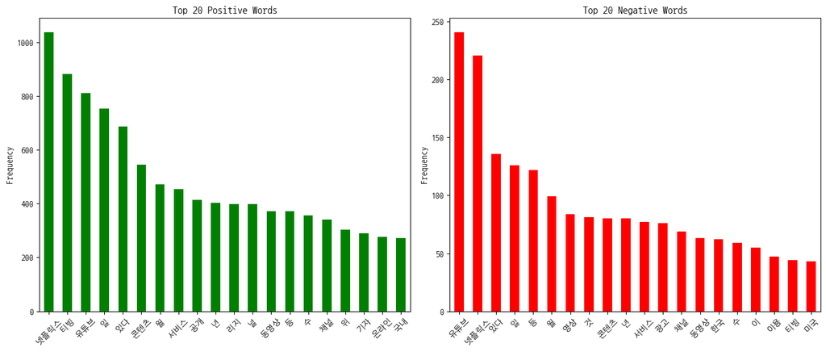

```python
y = final_df['label']
# 긍정 / 부정 나누기
X_pos = final_df[y == 1].drop('label', axis=1)
X_neg = final_df[y == 0].drop('label', axis=1)

# 빈도 합계
pos_freq = X_pos.sum().sort_values(ascending=False)[:20]
neg_freq = X_neg.sum().sort_values(ascending=False)[:20]

# 시각화
fig, axes = plt.subplots(1, 2, figsize=(14, 6))
pos_freq.plot(kind='bar', ax=axes[0], color='green', title='Top 20 Positive Words')
neg_freq.plot(kind='bar', ax=axes[1], color='red', title='Top 20 Negative Words')
axes[0].set_ylabel("Frequency")
axes[1].set_ylabel("Frequency")
axes[0].tick_params(axis='x', rotation=45)
axes[1].tick_params(axis='x', rotation=45)
plt.tight_layout()
plt.show()
```

#### noun, adjective가 띄어쓰기로 되어 있는 명사, 형용사로 이루어진 문자열

```python
def get_only_noun_adjective(sentence):
    noun_adjective = []
    okt = Okt()
    for word, pos in okt.pos(sentence, norm=True, stem=True):
        if pos in ('Noun', 'Adjective'):
            noun_adjective.append(word)
    return ' '.join(noun_adjective)

df['count_vector_noun_adjective'] = df['comment_fix'].apply(lambda x: get_only_noun_adjective(x))
df['count_vector_noun_adjective']
```

```
0       개발자 폴 메 소드 함 시스템 장애 로부터 유연하다 복구 실행 수 있다 또한 서킷 ...
1       넷플릭스 영화 드라마 주제 비교 위해 영상 메타데이터 설명 데이터 키 워드 내용 사...
2       넷플릭스 한국 최고 스토리 한자리 한국 아시아 태평양 지역 모든 영어권 국가 라틴아...
3       지브리 명작 편 넷플릭스 월 한국 포함 약 개국 넷플릭스 이웃집 토토 같다 스튜디오...
4       나 넷플릭스 시청 연대기 간만 카운터 펀치 당하다 하우스 오브 카드 나 흔하다 말 ...
                              ...
4180    유튜브 스튜디오 내 아이디어 탭 개편 곳 자신 스타일 알맞다 동영상 아이디어 제목 ...
4181    유튜브 후원 장 예찬 정치자금 법 위반 혐의 검찰 송치 기사 개인 유튜브 방송 중 ...
4182    씨 심 재판 모욕 인식 의사 가지 발언 방송 시청 중인 사람 피고인 제외 명 불과하...
4183    또한 유튜브 구글 동영상 생 성형 모델 쇼츠 통합 발표 앞 크리에이터 통해 생 배경...
4184    일 공정위 공정위 구글 유튜브 유튜브 뮤직 쿠팡 와우 멤버십 쿠팡 플레이 쿠팡 츠 ...
Name: count_vector_noun_adjective, Length: 4185, dtype: object
```

```python
final_df.columns
```

```
Index(['가', '가가', '가감', '가게', '가격', '가결', '가공', '가구', '가까이', '가깝다',
       ...
       '힌두교', '힌시테', '힐링', '힘', '힘드다', '힘들다', '힘차다', '힙', '힙합', 'label'],
      dtype='object', length=10081)
```

```python
X = df['count_vector_noun_adjective']
y = df['label']

X_train, X_test, y_train, y_test  = train_test_split(X, y, test_size=0.3, random_state=1234)
```

```python
vectorizer = CountVectorizer()  # Words consisting of a single character are ignored by default
vectorizer.fit(X)

X_train_vectorizer = vectorizer.transform(X_train)
X_test_vectorizer = vectorizer.transform(X_test)

print(vectorizer.get_feature_names_out())
```

```
['가가' '가감' '가게' ... '힘들다' '힘차다' '힙합']
```

```python
print(X_train_vectorizer.toarray())
```

```
[[0 0 0 ... 0 0 0]
 [0 0 0 ... 0 0 0]
 [0 0 0 ... 0 0 0]
 ...
 [0 0 0 ... 0 0 0]
 [0 0 0 ... 0 0 0]
 [0 0 0 ... 0 0 0]]
```

```python
print(X_train_vectorizer)
```

```
  (0, 985)	1
  (0, 1114)	1
  (0, 1927)	1
  (0, 2625)	1
  (0, 2765)	1
  (0, 3730)	1
  (0, 3992)	1
  (0, 4133)	1
  (0, 5429)	1
  (0, 5777)	1
  (0, 5969)	1
  (0, 6415)	1
  (0, 6580)	1
  (0, 7806)	1
  (0, 8946)	1
  (1, 88)	1
  (1, 126)	1
  (1, 1524)	1
  (1, 2373)	1
  (1, 2641)	1
  (1, 2758)	1
  (1, 3185)	1
  (1, 4134)	1
  (1, 4571)	1
  (1, 4629)	2
  :	:
  (2926, 5348)	1
  (2926, 5676)	1
  (2926, 6027)	1
  (2926, 7438)	1
  (2926, 8831)	1
  (2927, 523)	1
  (2927, 1339)	1
  (2927, 2236)	1
  (2927, 3317)	1
  (2927, 4629)	1
  (2927, 4670)	1
  (2928, 363)	1
  (2928, 1879)	1
  (2928, 2427)	1
  (2928, 2777)	2
  (2928, 3040)	1
  (2928, 3056)	1
  (2928, 3463)	1
  (2928, 4718)	2
  (2928, 4720)	1
  (2928, 6012)	1
  (2928, 6897)	1
  (2928, 7133)	2
  (2928, 7608)	1
  (2928, 8882)	1
```

```python
# CSR
print("[Row]\n", X_train_vectorizer.indptr)
print("[Column]\n", X_train_vectorizer.indices)
print("[Data]\n", X_train_vectorizer.data)
```

```
[Row]
 [    0    15    34 ... 43183 43189 43203]
[Column]
 [ 985 1114 1927 ... 7133 7608 8882]
[Data]
 [1 1 1 ... 2 1 1]
```

#### Logistic Regression(Classification)

```
Metrics 출력
Accuracy Score 0.8535031847133758
Precision Score 0.8823529411764706
Recall Score 0.9550561797752809
F1 Score 0.9172661870503597
ROC AUC Score 0.615825962228066
TPR 0.9550561797752809
FPR 0.723404255319149
------------------------------------------------------------------
```

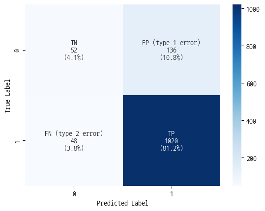

```python
lgc = LogisticRegression(random_state=42)
lgc.fit(X_train_vectorizer, y_train)
pred_y = lgc.predict(X_test_vectorizer)

cf_matrix = confusion_matrix(y_test.values, pred_y)
# annotation 준비
group_names = ["TN", "FP (type 1 error)", "FN (type 2 error)", "TP"]
group_counts = [value for value in cf_matrix.flatten()]
group_percentages = [f"{value:.1%}" for value in cf_matrix.flatten()/np.sum(cf_matrix)]
labels = [f"{v1}\n{v2}\n({v3})" for v1, v2, v3 in zip(group_names,group_counts,group_percentages)]
labels = np.asarray(labels).reshape(2,2)

# Metrics 출력
print("Metrics 출력")
print("Accuracy Score", accuracy_score(y_test, pred_y))
print("Precision Score", precision_score(y_test, pred_y))
print("Recall Score", recall_score(y_test, pred_y))
print("F1 Score", f1_score(y_test, pred_y))
print("ROC AUC Score", roc_auc_score(y_test, pred_y))
TN, FP, FN, TP = cf_matrix.ravel()
TPR = TP / (TP+FN)
FPR = FP / (FP+TN)
print("TPR", TPR)
print("FPR", FPR)
print("------------------------------------------------------------------")

# Confusion Matrix 시각화
sns.heatmap(cf_matrix, annot=labels, fmt='', cmap='Blues')
plt.xlabel('Predicted Label')
plt.ylabel('True Label')
```

#### DecisionTreeClassifier(Classification)

```
Metrics 출력
Accuracy Score 0.8128980891719745
Precision Score 0.8831646734130635
Recall Score 0.898876404494382
F1 Score 0.8909512761020882
ROC AUC Score 0.6116722448003825
TPR 0.898876404494382
FPR 0.675531914893617
------------------------------------------------------------------
```

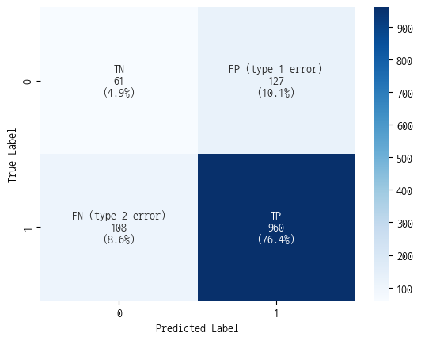

```python
dtc = DecisionTreeClassifier(random_state=42)
dtc.fit(X_train_vectorizer, y_train)
pred_y = dtc.predict(X_test_vectorizer)

cf_matrix = confusion_matrix(y_test.values, pred_y)
# annotation 준비
group_names = ["TN", "FP (type 1 error)", "FN (type 2 error)", "TP"]
group_counts = [value for value in cf_matrix.flatten()]
group_percentages = [f"{value:.1%}" for value in cf_matrix.flatten()/np.sum(cf_matrix)]
labels = [f"{v1}\n{v2}\n({v3})" for v1, v2, v3 in zip(group_names,group_counts,group_percentages)]
labels = np.asarray(labels).reshape(2,2)

# Metrics 출력
print("Metrics 출력")
print("Accuracy Score", accuracy_score(y_test, pred_y))
print("Precision Score", precision_score(y_test, pred_y))
print("Recall Score", recall_score(y_test, pred_y))
print("F1 Score", f1_score(y_test, pred_y))
print("ROC AUC Score", roc_auc_score(y_test, pred_y))
TN, FP, FN, TP = cf_matrix.ravel()
TPR = TP / (TP+FN)
FPR = FP / (FP+TN)
print("TPR", TPR)
print("FPR", FPR)
print("------------------------------------------------------------------")

# Confusion Matrix 시각화
sns.heatmap(cf_matrix, annot=labels, fmt='', cmap='Blues')
plt.xlabel('Predicted Label')
plt.ylabel('True Label')
```

#### SVM Classifier(Classification)

```
Metrics 출력
Accuracy Score 0.822452229299363
Precision Score 0.8901200369344414
Recall Score 0.9026217228464419
F1 Score 0.8963272896327289
ROC AUC Score 0.6348214997210933
TPR 0.9026217228464419
FPR 0.6329787234042553
------------------------------------------------------------------
```

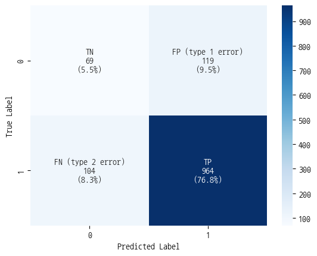

```python
svc = SVC(kernel='linear')
svc.fit(X_train_vectorizer, y_train)
pred_y = svc.predict(X_test_vectorizer)
cf_matrix = confusion_matrix(y_test.values, pred_y)

# annotation 준비
group_names = ["TN", "FP (type 1 error)", "FN (type 2 error)", "TP"]
group_counts = [value for value in cf_matrix.flatten()]
group_percentages = [f"{value:.1%}" for value in cf_matrix.flatten()/np.sum(cf_matrix)]
labels = [f"{v1}\n{v2}\n({v3})" for v1, v2, v3 in zip(group_names,group_counts,group_percentages)]
labels = np.asarray(labels).reshape(2,2)

# Metrics 출력
print("Metrics 출력")
print("Accuracy Score", accuracy_score(y_test, pred_y))
print("Precision Score", precision_score(y_test, pred_y))
print("Recall Score", recall_score(y_test, pred_y))
print("F1 Score", f1_score(y_test, pred_y))
print("ROC AUC Score", roc_auc_score(y_test, pred_y))
TN, FP, FN, TP = cf_matrix.ravel()
TPR = TP / (TP+FN)
FPR = FP / (FP+TN)
print("TPR", TPR)
print("FPR", FPR)
print("------------------------------------------------------------------")

# Confusion Matrix 시각화
sns.heatmap(cf_matrix, annot=labels, fmt='', cmap='Blues')
plt.xlabel('Predicted Label')
plt.ylabel('True Label')
```

#### Random Forest Classifier(Classification)

```
Metrics 출력
Accuracy Score 0.8614649681528662
Precision Score 0.8675986842105263
Recall Score 0.9878277153558053
F1 Score 0.9238178633975481
ROC AUC Score 0.5657223683162005
TPR 0.9878277153558053
FPR 0.8563829787234043
------------------------------------------------------------------
```

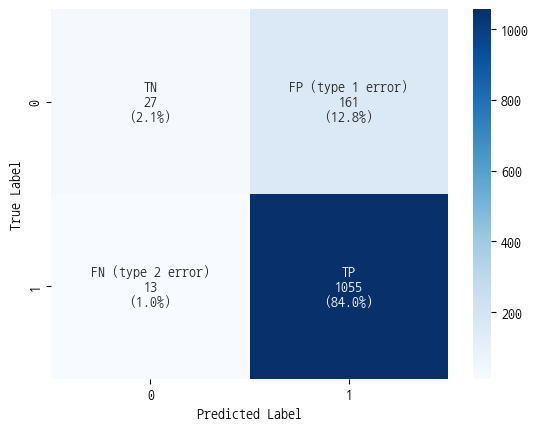

```python
rfc = RandomForestClassifier(random_state=42)
rfc.fit(X_train_vectorizer, y_train)
pred_y = rfc.predict(X_test_vectorizer)
cf_matrix = confusion_matrix(y_test.values, pred_y)

# annotation 준비
group_names = ["TN", "FP (type 1 error)", "FN (type 2 error)", "TP"]
group_counts = [value for value in cf_matrix.flatten()]
group_percentages = [f"{value:.1%}" for value in cf_matrix.flatten()/np.sum(cf_matrix)]
labels = [f"{v1}\n{v2}\n({v3})" for v1, v2, v3 in zip(group_names,group_counts,group_percentages)]
labels = np.asarray(labels).reshape(2,2)

# Metrics 출력
print("Metrics 출력")
print("Accuracy Score", accuracy_score(y_test, pred_y))
print("Precision Score", precision_score(y_test, pred_y))
print("Recall Score", recall_score(y_test, pred_y))
print("F1 Score", f1_score(y_test, pred_y))
print("ROC AUC Score", roc_auc_score(y_test, pred_y))
TN, FP, FN, TP = cf_matrix.ravel()
TPR = TP / (TP+FN)
FPR = FP / (FP+TN)
print("TPR", TPR)
print("FPR", FPR)
print("------------------------------------------------------------------")

# Confusion Matrix 시각화
sns.heatmap(cf_matrix, annot=labels, fmt='', cmap='Blues')
plt.xlabel('Predicted Label')
plt.ylabel('True Label')
```

#### KNeighborsClassifier(KNN-Classifier)

```python
knn_c = KNeighborsClassifier()
knn_c.fit(X_train_vectorizer, y_train)
pred_y = knn_c.predict(X_test_vectorizer)
cf_matrix = confusion_matrix(y_test.values, pred_y)

# annotation 준비
group_names = ["TN", "FP (type 1 error)", "FN (type 2 error)", "TP"]
group_counts = [value for value in cf_matrix.flatten()]
group_percentages = [f"{value:.1%}" for value in cf_matrix.flatten()/np.sum(cf_matrix)]
labels = [f"{v1}\n{v2}\n({v3})" for v1, v2, v3 in zip(group_names,group_counts,group_percentages)]
labels = np.asarray(labels).reshape(2,2)

# Metrics 출력
print("Metrics 출력")
print("Accuracy Score", accuracy_score(y_test, pred_y))
print("Precision Score", precision_score(y_test, pred_y))
print("Recall Score", recall_score(y_test, pred_y))
print("F1 Score", f1_score(y_test, pred_y))
print("ROC AUC Score", roc_auc_score(y_test, pred_y))
TN, FP, FN, TP = cf_matrix.ravel()
TPR = TP / (TP+FN)
FPR = FP / (FP+TN)
print("TPR", TPR)
print("FPR", FPR)
print("------------------------------------------------------------------")

# Confusion Matrix 시각화
sns.heatmap(cf_matrix, annot=labels, fmt='', cmap='Blues')
plt.xlabel('Predicted Label')
plt.ylabel('True Label')
```

[output not shown]

```
Metrics 출력
Accuracy Score 0.8503184713375797
Precision Score 0.8600654664484452
Recall Score 0.9840823970037453
F1 Score 0.9179039301310044
ROC AUC Score 0.5372539644593195
TPR 0.9840823970037453
FPR 0.9095744680851063
------------------------------------------------------------------
```

#### Voting Classifier(Hard Voting) (Logistic Regression, RandomForestClassifier, NaiveBayes, SVM Classifer, KNN-Classifier)

```
Metrics 출력
Accuracy Score 0.8590764331210191
Precision Score 0.8753159224936815
Recall Score 0.9728464419475655
F1 Score 0.9215077605321507
ROC AUC Score 0.592806199697187
TPR 0.9728464419475655
FPR 0.7872340425531915
------------------------------------------------------------------
```

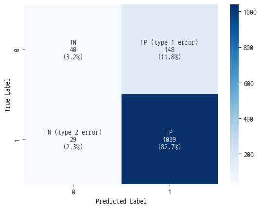

```python
clf1 = LogisticRegression(random_state=42)
clf2 = RandomForestClassifier(random_state=42)
clf3 = GaussianNB()
clf4 = SVC(kernel='linear', probability=True)  # soft voting을 위해선 probability=True 필요
clf5 = KNeighborsClassifier()

voting_clf = VotingClassifier(
    estimators=[
        ('log_reg', clf1),
        ('ran_fst', clf2),
        ('gau_nb', clf3),
        ('svc', clf4),
        ('knn', clf5)
    ],
    voting='hard'  # 또는 'soft'
)
voting_clf.fit(X_train_vectorizer.toarray(), y_train)
pred_y = voting_clf.predict(X_test_vectorizer.toarray())
cf_matrix = confusion_matrix(y_test.values, pred_y)

# annotation 준비
group_names = ["TN", "FP (type 1 error)", "FN (type 2 error)", "TP"]
group_counts = [value for value in cf_matrix.flatten()]
group_percentages = [f"{value:.1%}" for value in cf_matrix.flatten()/np.sum(cf_matrix)]
labels = [f"{v1}\n{v2}\n({v3})" for v1, v2, v3 in zip(group_names,group_counts,group_percentages)]
labels = np.asarray(labels).reshape(2,2)

# Metrics 출력
print("Metrics 출력")
print("Accuracy Score", accuracy_score(y_test, pred_y))
print("Precision Score", precision_score(y_test, pred_y))
print("Recall Score", recall_score(y_test, pred_y))
print("F1 Score", f1_score(y_test, pred_y))
print("ROC AUC Score", roc_auc_score(y_test, pred_y))
TN, FP, FN, TP = cf_matrix.ravel()
TPR = TP / (TP+FN)
FPR = FP / (FP+TN)
print("TPR", TPR)
print("FPR", FPR)
print("------------------------------------------------------------------")

# Confusion Matrix 시각화
sns.heatmap(cf_matrix, annot=labels, fmt='', cmap='Blues')
plt.xlabel('Predicted Label')
plt.ylabel('True Label')
```

#### BaggingClassifier base: DecisionTreeClassifier(Classification)

```
Metrics 출력
Accuracy Score 0.8272292993630573
Precision Score 0.8729184925503944
Recall Score 0.9325842696629213
F1 Score 0.901765504753282
ROC AUC Score 0.5806538369591202
TPR 0.9325842696629213
FPR 0.7712765957446809
------------------------------------------------------------------
```

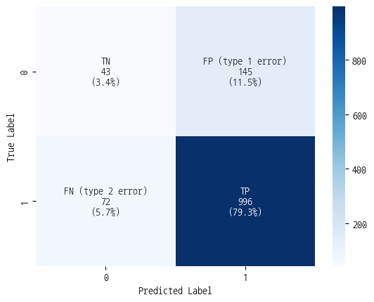

```python
clf = DecisionTreeClassifier(random_state=42)
bagclf = BaggingClassifier(clf, n_estimators=3, bootstrap=True)
bagclf.fit(X_train_vectorizer, y_train)
pred_y = bagclf.predict(X_test_vectorizer)
cf_matrix = confusion_matrix(y_test.values, pred_y)

# annotation 준비
group_names = ["TN", "FP (type 1 error)", "FN (type 2 error)", "TP"]
group_counts = [value for value in cf_matrix.flatten()]
group_percentages = [f"{value:.1%}" for value in cf_matrix.flatten()/np.sum(cf_matrix)]
labels = [f"{v1}\n{v2}\n({v3})" for v1, v2, v3 in zip(group_names,group_counts,group_percentages)]
labels = np.asarray(labels).reshape(2,2)

# Metrics 출력
print("Metrics 출력")
print("Accuracy Score", accuracy_score(y_test, pred_y))
print("Precision Score", precision_score(y_test, pred_y))
print("Recall Score", recall_score(y_test, pred_y))
print("F1 Score", f1_score(y_test, pred_y))
print("ROC AUC Score", roc_auc_score(y_test, pred_y))
TN, FP, FN, TP = cf_matrix.ravel()
TPR = TP / (TP+FN)
FPR = FP / (FP+TN)
print("TPR", TPR)
print("FPR", FPR)
print("------------------------------------------------------------------")

# Confusion Matrix 시각화
sns.heatmap(cf_matrix, annot=labels, fmt='', cmap='Blues')
plt.xlabel('Predicted Label')
plt.ylabel('True Label')
```

#### BaggingClassifier(base: Logistic Regression)

```
Metrics 출력
Accuracy Score 0.8535031847133758
Precision Score 0.8823529411764706
Recall Score 0.9550561797752809
F1 Score 0.9172661870503597
ROC AUC Score 0.615825962228066
TPR 0.9550561797752809
FPR 0.723404255319149
------------------------------------------------------------------
```

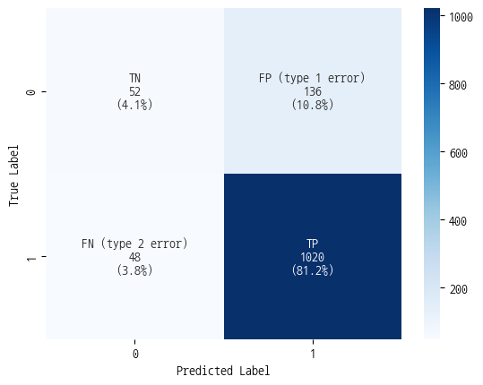

```python
clf = LogisticRegression()
bagclf = BaggingClassifier(clf, n_estimators=3, bootstrap=False)
bagclf.fit(X_train_vectorizer, y_train)
pred_y = bagclf.predict(X_test_vectorizer)
cf_matrix = confusion_matrix(y_test.values, pred_y)

# annotation 준비
group_names = ["TN", "FP (type 1 error)", "FN (type 2 error)", "TP"]
group_counts = [value for value in cf_matrix.flatten()]
group_percentages = [f"{value:.1%}" for value in cf_matrix.flatten()/np.sum(cf_matrix)]
labels = [f"{v1}\n{v2}\n({v3})" for v1, v2, v3 in zip(group_names,group_counts,group_percentages)]
labels = np.asarray(labels).reshape(2,2)

# Metrics 출력
print("Metrics 출력")
print("Accuracy Score", accuracy_score(y_test, pred_y))
print("Precision Score", precision_score(y_test, pred_y))
print("Recall Score", recall_score(y_test, pred_y))
print("F1 Score", f1_score(y_test, pred_y))
print("ROC AUC Score", roc_auc_score(y_test, pred_y))
TN, FP, FN, TP = cf_matrix.ravel()
TPR = TP / (TP+FN)
FPR = FP / (FP+TN)
print("TPR", TPR)
print("FPR", FPR)
print("------------------------------------------------------------------")

# Confusion Matrix 시각화
sns.heatmap(cf_matrix, annot=labels, fmt='', cmap='Blues')
plt.xlabel('Predicted Label')
plt.ylabel('True Label')
```